# Analyzing the Reptile data for State of Nature Report 2023

```r
cat('PHI = ');  deviance(Forest.sp.rich.model.full.Poisson)/df.residual(Forest.sp.rich.model.full.Poisson)
```

```
## PHI =
```

```
## [1] 0.8193946
```

```r
drop1(Forest.sp.rich.model.full.Poisson) # Can drop cosine distance to noon
```

```
## Single term deletions
##
## Model:
## species.richness ~ subunit + sin.dist.21.June + cos.dist.21.June +
##     sin.dist.noon + cos.dist.noon + (1 | site)
##                  Df    AIC
## <none>              627.51
## subunit           2 627.97
## sin.dist.21.June  1 632.61
## cos.dist.21.June  1 630.91
## sin.dist.noon     1 626.99
## cos.dist.noon     1 625.65
```

PHI < 1 so we proceed with Poisson models. We can drop cosine diel pattern:

```r
Forest.sp.rich.model1 <- glmmTMB(species.richness ~ subunit + sin.dist.21.June + cos.dist.21.June +
                                              sin.dist.noon + (1|site), family = 'poisson', data = Forest)
summary(Forest.sp.rich.model1)
```

```
##  Family: poisson  ( log )
## Formula:
## species.richness ~ subunit + sin.dist.21.June + cos.dist.21.June +
##     sin.dist.noon + (1 | site)
## Data: Forest
##
##      AIC      BIC   logLik deviance df.resid
##    625.6    649.5   -305.8    611.6      215
##
## Random effects:
##
## Conditional model:
##  Groups Name        Variance Std.Dev.
##  site   (Intercept) 0.03299  0.1816
## Number of obs: 222, groups:  site, 15
##
## Conditional model:
##                  Estimate Std. Error z value Pr(>|z|)
## (Intercept)        0.4862     0.1476   3.294 0.000987 ***
## subunitCarmel      0.2473     0.1860   1.330 0.183643
## subunitGalilee    -0.2038     0.2115  -0.963 0.335313
## sin.dist.21.June  -0.3055     0.1156  -2.644 0.008205 **
## cos.dist.21.June  -0.3234     0.1318  -2.454 0.014144 *
## sin.dist.noon      0.1658     0.1305   1.271 0.203817
## ---
## Signif. codes:  0 '***' 0.001 '**' 0.01 '*' 0.05 '.' 0.1 ' ' 1
```

```r
drop1(Forest.sp.rich.model1) # Can drop cosine distance to noon
```

```
## Single term deletions
##
## Model:
## species.richness ~ subunit + sin.dist.21.June + cos.dist.21.June +
##     sin.dist.noon + (1 | site)
##                  Df    AIC
## <none>              625.65
## subunit           2 626.18
## sin.dist.21.June  1 630.69
## cos.dist.21.June  1 629.28
## sin.dist.noon     1 625.27
```

We can drop the subunit since delta AIC < 2 if we do:

```r
Forest.sp.rich.model2 <- glmmTMB(species.richness ~ sin.dist.21.June + cos.dist.21.June +
                                              sin.dist.noon + (1|site), family = 'poisson', data = Forest)
summary(Forest.sp.rich.model2)
```

```
##  Family: poisson  ( log )
## Formula:
## species.richness ~ sin.dist.21.June + cos.dist.21.June + sin.dist.noon +
##     (1 | site)
## Data: Forest
##
##      AIC      BIC   logLik deviance df.resid
##    626.2    643.2   -308.1    616.2      217
##
## Random effects:
##
## Conditional model:
##  Groups Name        Variance Std.Dev.
##  site   (Intercept) 0.06544  0.2558
## Number of obs: 222, groups:  site, 15
##
## Conditional model:
##                  Estimate Std. Error z value Pr(>|z|)
## (Intercept)        0.4760     0.1176   4.047 5.19e-05 ***
## sin.dist.21.June  -0.2644     0.1109  -2.385   0.0171 *
## cos.dist.21.June  -0.2802     0.1310  -2.139   0.0324 *
## sin.dist.noon      0.2287     0.1220   1.874   0.0609 .
## ---
## Signif. codes:  0 '***' 0.001 '**' 0.01 '*' 0.05 '.' 0.1 ' ' 1
```

```r
drop1(Forest.sp.rich.model2) # Can drop cosine distance to noon
```

```
## Single term deletions
##
## Model:
## species.richness ~ sin.dist.21.June + cos.dist.21.June + sin.dist.noon +
##     (1 | site)
##                  Df    AIC
## <none>              626.18
## sin.dist.21.June  1 629.89
## cos.dist.21.June  1 628.54
## sin.dist.noon     1 627.63
```

No more predictors to drop. Proceed to model diagnostics:

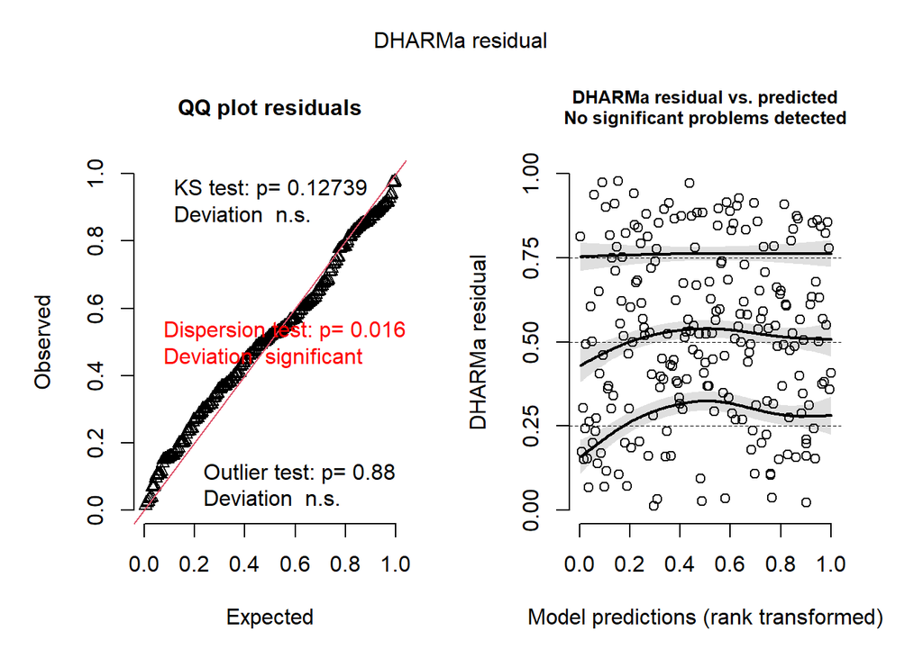

```r
forest.sp.rich.sim.res <- simulateResiduals(Forest.sp.rich.model2)
plot(forest.sp.rich.sim.res)
```

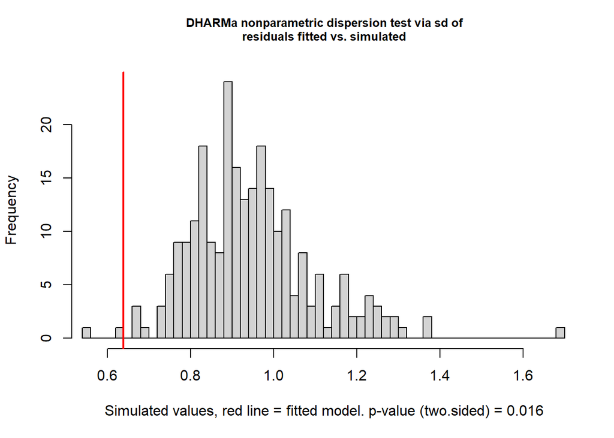

```
##
##  DHARMa nonparametric dispersion test via sd of residuals fitted vs.
##  simulated
##
## data:  simulationOutput
## dispersion = 0.67355, p-value = 0.016
## alternative hypothesis: two.sided
```

```r
testDispersion(forest.sp.rich.sim.res)
```

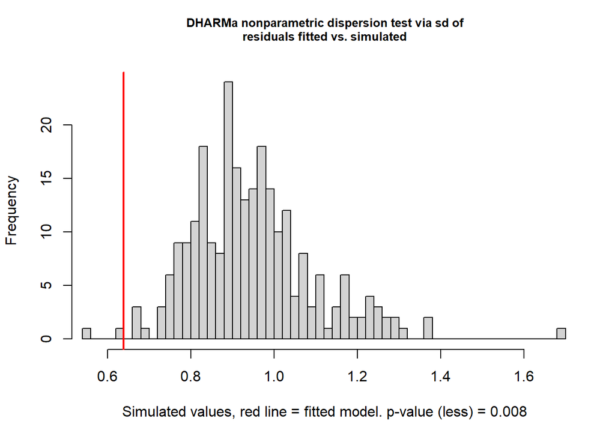

```
##
##  DHARMa nonparametric dispersion test via sd of residuals fitted vs.
##  simulated
##
## data:  simulationOutput
## dispersion = 0.67355, p-value = 0.008
## alternative hypothesis: less
```

```r
testDispersion(forest.sp.rich.sim.res, alternative = 'less')
```

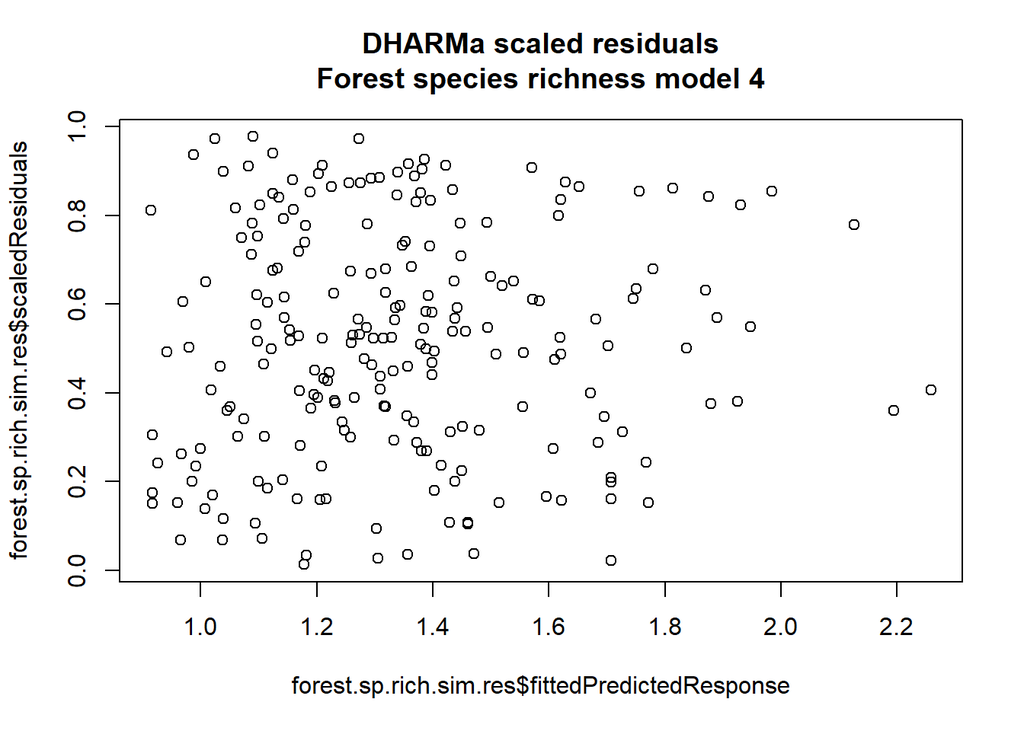

```r
plot(forest.sp.rich.sim.res$fittedPredictedResponse, forest.sp.rich.sim.res$scaledResiduals, main = 'DHARMa scaled residuals\nForest species richness model 4')
```

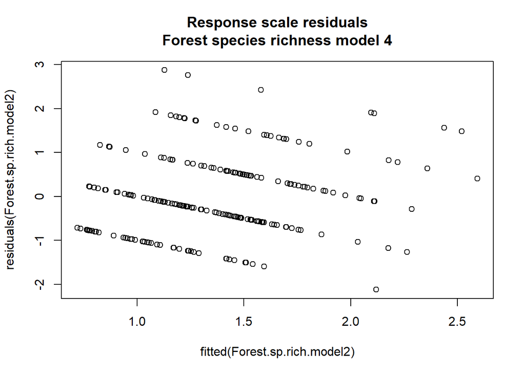

```r
plot(fitted(Forest.sp.rich.model2), residuals(Forest.sp.rich.model2), main = 'Response scale residuals\nForest species richness model 4')
```

We have clear indications of under-dispersion (yes, again), which means we have lower statistical power. Back up and document species richness models:

```r
# The chosen model is Forest.sp.rich.model2 (time of day and season)
# capture.output(cat('The best fitting model for species richness in the planted forest is Forest.sp.rich.model2.\n'),
#                summary(Forest.sp.rich.model2), cat('\n------\n'),
#                file = '../output/Planted conifer forest species richness best fitting model.txt')

for(model in ls()[grep('*Forest.sp.rich.model.', ls())]){
  sp.rich.comparison <- rbind(sp.rich.comparison,
                              data.table(unit = 'Planted Conifer Forest', model = model,
                                         no.of.preds = length(attr(get(model)$modelInfo$terms$cond$fixed, 'term.labels')),
                                         AIC = AIC(get(model)), BIC = BIC(get(model)),
                                         data = as.character(get(model)$call$data),
                                         family = as.character(get(model)$call$family),
                                         formula = as.character(get(model)$call$formula)))
}
sp.rich.comparison <- sp.rich.comparison[!(formula %like% '~' | formula %like% 'species.richness')] # remove redundant rows
sp.rich.comparison <- unique(sp.rich.comparison)
setorder(sp.rich.comparison, unit, AIC)  # Sort by AIC (ascending)
sp.rich.comparison[unit == 'Planted Conifer Forest', .(model, family, formula, no.of.preds, AIC, BIC)] # View the table
```

```
##                                model  family
##                               <char>  <char>
## 1:             Forest.sp.rich.model1 poisson
## 2:             Forest.sp.rich.model2 poisson
## 3: Forest.sp.rich.model.full.Poisson poisson
##                                                                                       formula
##                                                                                        <char>
## 1:                 subunit + sin.dist.21.June + cos.dist.21.June + sin.dist.noon + (1 | site)
## 2:                           sin.dist.21.June + cos.dist.21.June + sin.dist.noon + (1 | site)
## 3: subunit + sin.dist.21.June + cos.dist.21.June + sin.dist.noon + cos.dist.noon + (1 | site)
##    no.of.preds      AIC      BIC
##          <num>    <num>    <num>
## 1:           4 625.6481 649.4668
## 2:           3 626.1826 643.1960
## 3:           5 627.5099 654.7313
```

```r
rm(list = setdiff(ls()[grep('*Forest.sp.rich.model', ls())], c('Forest.sp.rich.model2'))) # Clean up
```

Again, no researcher’s hypotheses were confirmed so we do not explore the chosen model’s predictions but continue directly to total abundance:

```r
## Forest total abundance----
str(Forest)
```

```
## Classes 'data.table' and 'data.frame':   222 obs. of  23 variables:
##  $ unit               : Factor w/ 5 levels "Coastal Plain Sands",..: 5 5 5 5 5 5 5 5 5 5 ...
##  $ year               : num  2014 2014 2014 2014 2014 ...
##  $ campaign           : Factor w/ 5 levels "T0","T1","T2",..: 1 1 1 1 1 1 1 1 1 1 ...
##  $ subunit            : Factor w/ 3 levels "Judean Highlands",..: 2 2 2 2 2 2 2 2 2 2 ...
##  $ site               : Factor w/ 35 levels "Aderet","Amatzia",..: 5 5 5 10 10 10 18 18 18 27 ...
##  $ point_name         : Factor w/ 281 levels "Aderet 31.67144877_34.9880248",..: 32 33 34 81 83 85 134 135 136 213 ...
##  $ survey_ID          : Factor w/ 691 levels "T0_Aderet 31.67867469_34.98154177",..: 25 26 27 37 38 39 61 62 63 109 ...
##  $ Date               : Date, format: "2014-07-30" "2014-07-30" ...
##  $ sin.dist.21.June   : num  0.622 0.622 0.622 0.509 0.509 ...
##  $ cos.dist.21.June   : num  0.783 0.783 0.783 0.861 0.861 ...
##  $ sin.dist.noon      : num  0.174 0.288 0.626 0.187 0.577 ...
##  $ cos.dist.noon      : num  0.985 0.958 0.78 0.982 0.817 ...
##  $ settlements        : Factor w/ 2 levels "Far","Near": NA NA NA NA NA NA NA NA NA NA ...
##  $ agriculture        : Factor w/ 2 levels "Far","Near": NA NA NA NA NA NA NA NA NA NA ...
##  $ dunes              : Factor w/ 2 levels "semi-shifting",..: NA NA NA NA NA NA NA NA NA NA ...
##  $ habitat            : Factor w/ 3 levels "bedouin agriculture",..: NA NA NA NA NA NA NA NA NA NA ...
##  $ mean.lon           : num  NaN NaN 35 35.1 35.1 ...
##  $ mean.lat           : num  NaN NaN 32.6 32.7 32.7 ...
##  $ species.richness   : num  0 0 1 1 1 1 1 2 0 1 ...
##  $ total.abundance    : num  0 0 1 1 2 2 1 4 0 1 ...
##  $ geom.mean.abundance: num  0 0 1 1 2 2 1 3 0 1 ...
##  $ year.count         : num  0 0 0 0 0 0 0 0 0 0 ...
##  $ year.fct           : Factor w/ 8 levels "2014","2015",..: 1 1 1 1 1 1 1 1 1 1 ...
##  - attr(*, "sorted")= chr "unit"
##  - attr(*, ".internal.selfref")=<externalptr>
```

```r
Forest[is.na(year)] # no missing variables
```

```
## Key: <unit>
## Empty data.table (0 rows and 23 cols): unit,year,campaign,subunit,site,point_name...
```

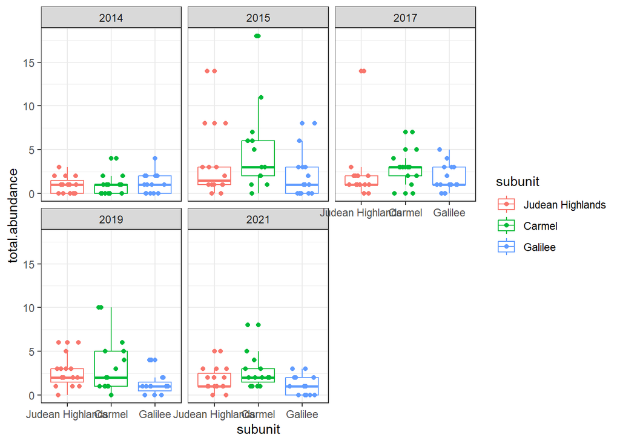

```r
# The relevant predictor is the subunit and the temporal trend
# Plot total abundance
ggplot(data = Forest, aes(x = subunit, y = total.abundance, color = subunit)) + geom_boxplot() +
  geom_jitter(height = 0, width = 0.3) + facet_wrap(.~ year) + theme_bw()
```

Subunit and annual differences seem minor; Galilee could be lower. Start model selection for total reptile abundance:

```r
# Full model, Poisson response
Forest.abnd.model.full.Poisson <- glmmTMB(total.abundance ~ subunit * year.count + sin.dist.21.June + cos.dist.21.June +
                                               sin.dist.noon + cos.dist.noon + (1|site) , family = 'poisson', data = Forest)
summary(Forest.abnd.model.full.Poisson)
```

```
##  Family: poisson  ( log )
## Formula:
## total.abundance ~ subunit * year.count + sin.dist.21.June + cos.dist.21.June +
##     sin.dist.noon + cos.dist.noon + (1 | site)
## Data: Forest
##
##      AIC      BIC   logLik deviance df.resid
##    818.9    856.3   -398.4    796.9      211
##
## Random effects:
##
## Conditional model:
##  Groups Name        Variance Std.Dev.
##  site   (Intercept) 0.1794   0.4235
## Number of obs: 222, groups:  site, 15
##
## Conditional model:
##                            Estimate Std. Error z value Pr(>|z|)
## (Intercept)                0.448615   0.381127   1.177  0.23917
## subunitCarmel              0.539167   0.329005   1.639  0.10126
## subunitGalilee            -0.010725   0.350894  -0.031  0.97562
## year.count                 0.025661   0.042932   0.598  0.55003
## sin.dist.21.June          -0.418648   0.128418  -3.260  0.00111 **
## cos.dist.21.June          -0.886656   0.104084  -8.519  < 2e-16 ***
## sin.dist.noon              0.266390   0.125490   2.123  0.03377 *
## cos.dist.noon              0.423636   0.312875   1.354  0.17573
## subunitCarmel:year.count   0.061927   0.046123   1.343  0.17939
## subunitGalilee:year.count  0.008439   0.055366   0.152  0.87886
## ---
## Signif. codes:  0 '***' 0.001 '**' 0.01 '*' 0.05 '.' 0.1 ' ' 1
```

```r
cat('PHI = '); deviance(Forest.abnd.model.full.Poisson)/df.residual(Forest.abnd.model.full.Poisson)
```

```
## PHI =
```

```
## [1] 1.37216
```

```r
drop1(Forest.abnd.model.full.Poisson)
```

```
## Single term deletions
##
## Model:
## total.abundance ~ subunit * year.count + sin.dist.21.June + cos.dist.21.June +
##     sin.dist.noon + cos.dist.noon + (1 | site)
##                    Df    AIC
## <none>                818.89
## sin.dist.21.June    1 827.44
## cos.dist.21.June    1 886.49
## sin.dist.noon       1 821.39
## cos.dist.noon       1 818.75
## subunit:year.count  2 817.11
```

```r
Forest.abnd.model.full.NB <- glmmTMB(total.abundance ~ subunit * year.count + sin.dist.21.June + cos.dist.21.June +
                                               sin.dist.noon + cos.dist.noon + (1|site) , family = 'nbinom2', data = Forest)
summary(Forest.abnd.model.full.NB)
```

```
##  Family: nbinom2  ( log )
## Formula:
## total.abundance ~ subunit * year.count + sin.dist.21.June + cos.dist.21.June +
##     sin.dist.noon + cos.dist.noon + (1 | site)
## Data: Forest
##
##      AIC      BIC   logLik deviance df.resid
##    804.9    845.7   -390.5    780.9      210
##
## Random effects:
##
## Conditional model:
##  Groups Name        Variance Std.Dev.
##  site   (Intercept) 0.1623   0.4029
## Number of obs: 222, groups:  site, 15
##
## Dispersion parameter for nbinom2 family (): 6.02
##
## Conditional model:
##                             Estimate Std. Error z value Pr(>|z|)
## (Intercept)                0.4925715  0.4247640   1.160  0.24620
## subunitCarmel              0.4942363  0.3431347   1.440  0.14977
## subunitGalilee             0.0374682  0.3647828   0.103  0.91819
## year.count                 0.0231497  0.0517533   0.447  0.65465
## sin.dist.21.June          -0.4216660  0.1528912  -2.758  0.00582 **
## cos.dist.21.June          -0.8463017  0.1282981  -6.596 4.21e-11 ***
## sin.dist.noon              0.2705339  0.1460645   1.852  0.06400 .
## cos.dist.noon              0.3676373  0.3579742   1.027  0.30442
## subunitCarmel:year.count   0.0678891  0.0567515   1.196  0.23160
## subunitGalilee:year.count  0.0008804  0.0636932   0.014  0.98897
## ---
## Signif. codes:  0 '***' 0.001 '**' 0.01 '*' 0.05 '.' 0.1 ' ' 1
```

```r
drop1(Forest.abnd.model.full.NB)
```

```
## Single term deletions
##
## Model:
## total.abundance ~ subunit * year.count + sin.dist.21.June + cos.dist.21.June +
##     sin.dist.noon + cos.dist.noon + (1 | site)
##                    Df    AIC
## <none>                804.90
## sin.dist.21.June    1 810.39
## cos.dist.21.June    1 840.89
## sin.dist.noon       1 806.33
## cos.dist.noon       1 803.96
## subunit:year.count  2 802.89
```

AIC is clearly lower for the negative binomial model. We can drop the interaction between year and trend:

```r
Forest.abnd.model1 <- glmmTMB(total.abundance ~ subunit + year.count + sin.dist.21.June + cos.dist.21.June +
                                               sin.dist.noon + cos.dist.noon + (1|site) , family = 'nbinom2', data = Forest)
summary(Forest.abnd.model1)
```

```
##  Family: nbinom2  ( log )
## Formula:
## total.abundance ~ subunit + year.count + sin.dist.21.June + cos.dist.21.June +
##     sin.dist.noon + cos.dist.noon + (1 | site)
## Data: Forest
##
##      AIC      BIC   logLik deviance df.resid
##    802.9    836.9   -391.4    782.9      212
##
## Random effects:
##
## Conditional model:
##  Groups Name        Variance Std.Dev.
##  site   (Intercept) 0.1642   0.4052
## Number of obs: 222, groups:  site, 15
##
## Dispersion parameter for nbinom2 family (): 5.94
##
## Conditional model:
##                  Estimate Std. Error z value Pr(>|z|)
## (Intercept)       0.34692    0.40908   0.848  0.39641
## subunitCarmel     0.70676    0.29808   2.371  0.01774 *
## subunitGalilee    0.02178    0.31771   0.069  0.94536
## year.count        0.05481    0.03436   1.596  0.11060
## sin.dist.21.June -0.38552    0.14684  -2.625  0.00865 **
## cos.dist.21.June -0.83343    0.12796  -6.513 7.35e-11 ***
## sin.dist.noon     0.21813    0.13928   1.566  0.11730
## cos.dist.noon     0.41964    0.35250   1.190  0.23386
## ---
## Signif. codes:  0 '***' 0.001 '**' 0.01 '*' 0.05 '.' 0.1 ' ' 1
```

```r
drop1(Forest.abnd.model1)
```

```
## Single term deletions
##
## Model:
## total.abundance ~ subunit + year.count + sin.dist.21.June + cos.dist.21.June +
##     sin.dist.noon + cos.dist.noon + (1 | site)
##                  Df    AIC
## <none>              802.89
## subunit           2 804.86
## year.count        1 803.40
## sin.dist.21.June  1 807.72
## cos.dist.21.June  1 837.71
## sin.dist.noon     1 803.34
## cos.dist.noon     1 802.32
```

We can further drop the cosine diel pattern:

```r
Forest.abnd.model2 <- glmmTMB(total.abundance ~ subunit + year.count + sin.dist.21.June + cos.dist.21.June +
                                               sin.dist.noon + (1|site) , family = 'nbinom2', data = Forest)
summary(Forest.abnd.model2)
```

```
##  Family: nbinom2  ( log )
## Formula:
## total.abundance ~ subunit + year.count + sin.dist.21.June + cos.dist.21.June +
##     sin.dist.noon + (1 | site)
## Data: Forest
##
##      AIC      BIC   logLik deviance df.resid
##    802.3    832.9   -392.2    784.3      213
##
## Random effects:
##
## Conditional model:
##  Groups Name        Variance Std.Dev.
##  site   (Intercept) 0.1634   0.4043
## Number of obs: 222, groups:  site, 15
##
## Dispersion parameter for nbinom2 family (): 5.77
##
## Conditional model:
##                  Estimate Std. Error z value Pr(>|z|)
## (Intercept)       0.73916    0.24294   3.043  0.00235 **
## subunitCarmel     0.69073    0.29750   2.322  0.02024 *
## subunitGalilee   -0.02243    0.31605  -0.071  0.94342
## year.count        0.04826    0.03399   1.420  0.15565
## sin.dist.21.June -0.40109    0.14613  -2.745  0.00605 **
## cos.dist.21.June -0.85194    0.12753  -6.680 2.38e-11 ***
## sin.dist.noon     0.24317    0.13736   1.770  0.07667 .
## ---
## Signif. codes:  0 '***' 0.001 '**' 0.01 '*' 0.05 '.' 0.1 ' ' 1
```

```r
drop1(Forest.abnd.model2)
```

```
## Single term deletions
##
## Model:
## total.abundance ~ subunit + year.count + sin.dist.21.June + cos.dist.21.June +
##     sin.dist.noon + (1 | site)
##                  Df    AIC
## <none>              802.32
## subunit           2 804.36
## year.count        1 802.31
## sin.dist.21.June  1 807.77
## cos.dist.21.June  1 838.95
## sin.dist.noon     1 803.45
```

Next, drop the trend:

```r
Forest.abnd.model3 <- glmmTMB(total.abundance ~ subunit + sin.dist.21.June + cos.dist.21.June +
                                               sin.dist.noon + (1|site) , family = 'nbinom2', data = Forest)
summary(Forest.abnd.model3)
```

```
##  Family: nbinom2  ( log )
## Formula:
## total.abundance ~ subunit + sin.dist.21.June + cos.dist.21.June +
##     sin.dist.noon + (1 | site)
## Data: Forest
##
##      AIC      BIC   logLik deviance df.resid
##    802.3    829.5   -393.2    786.3      214
##
## Random effects:
##
## Conditional model:
##  Groups Name        Variance Std.Dev.
##  site   (Intercept) 0.1497   0.3869
## Number of obs: 222, groups:  site, 15
##
## Dispersion parameter for nbinom2 family (): 5.47
##
## Conditional model:
##                  Estimate Std. Error z value Pr(>|z|)
## (Intercept)       0.88141    0.21508   4.098 4.17e-05 ***
## subunitCarmel     0.71098    0.28812   2.468   0.0136 *
## subunitGalilee   -0.05278    0.30672  -0.172   0.8634
## sin.dist.21.June -0.51820    0.12106  -4.280 1.87e-05 ***
## cos.dist.21.June -0.80927    0.12469  -6.490 8.56e-11 ***
## sin.dist.noon     0.21602    0.13668   1.581   0.1140
## ---
## Signif. codes:  0 '***' 0.001 '**' 0.01 '*' 0.05 '.' 0.1 ' ' 1
```

```r
drop1(Forest.abnd.model3)
```

```
## Single term deletions
##
## Model:
## total.abundance ~ subunit + sin.dist.21.June + cos.dist.21.June +
##     sin.dist.noon + (1 | site)
##                  Df    AIC
## <none>              802.31
## subunit           2 805.30
## sin.dist.21.June  1 818.35
## cos.dist.21.June  1 836.95
## sin.dist.noon     1 802.81
```

No more predictors to drop. Proceed to model diagnostics:

```r
# The chosen model is Forest.abnd.model3 (subunit, diel pattern and seasonality with site ID)
summary(Forest.abnd.model3)
```

```
##  Family: nbinom2  ( log )
## Formula:
## total.abundance ~ subunit + sin.dist.21.June + cos.dist.21.June +
##     sin.dist.noon + (1 | site)
## Data: Forest
##
##      AIC      BIC   logLik deviance df.resid
##    802.3    829.5   -393.2    786.3      214
##
## Random effects:
##
## Conditional model:
##  Groups Name        Variance Std.Dev.
##  site   (Intercept) 0.1497   0.3869
## Number of obs: 222, groups:  site, 15
##
## Dispersion parameter for nbinom2 family (): 5.47
##
## Conditional model:
##                  Estimate Std. Error z value Pr(>|z|)
## (Intercept)       0.88141    0.21508   4.098 4.17e-05 ***
## subunitCarmel     0.71098    0.28812   2.468   0.0136 *
## subunitGalilee   -0.05278    0.30672  -0.172   0.8634
## sin.dist.21.June -0.51820    0.12106  -4.280 1.87e-05 ***
## cos.dist.21.June -0.80927    0.12469  -6.490 8.56e-11 ***
## sin.dist.noon     0.21602    0.13668   1.581   0.1140
## ---
## Signif. codes:  0 '***' 0.001 '**' 0.01 '*' 0.05 '.' 0.1 ' ' 1
```

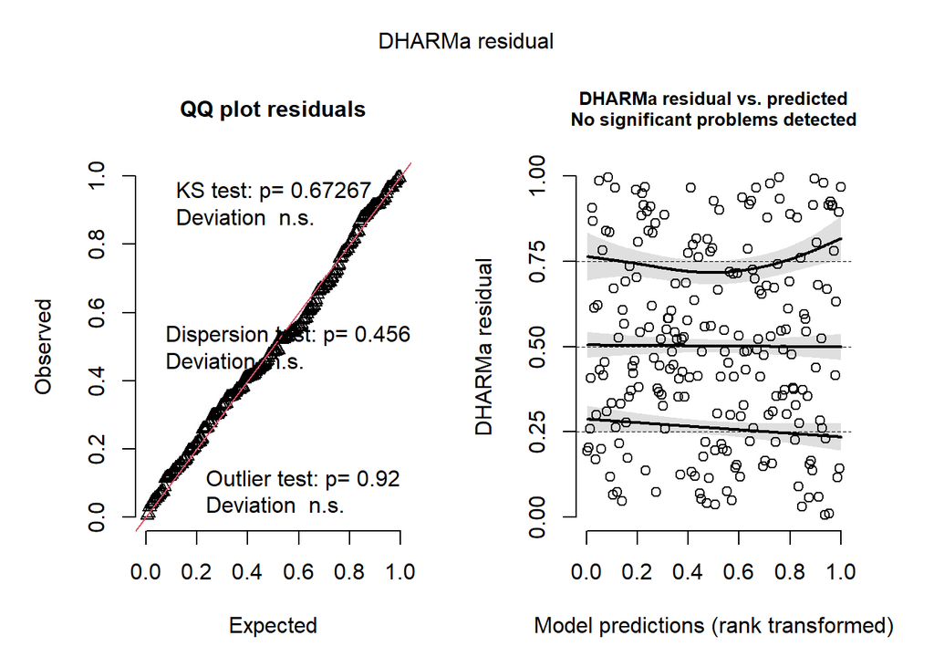

```r
forest.abnd.sim.res <- simulateResiduals(Forest.abnd.model3)
plot(forest.abnd.sim.res) # QQ plot seems ok; all tests are ok (non-significant)
```

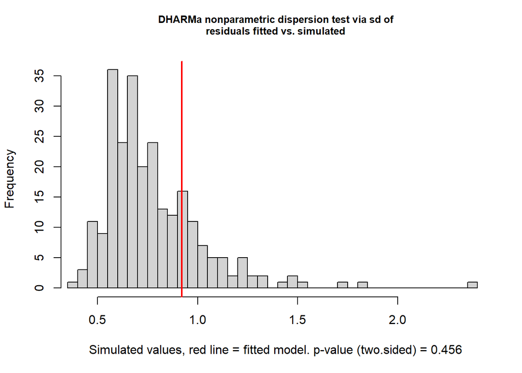

```
##
##  DHARMa nonparametric dispersion test via sd of residuals fitted vs.
##  simulated
##
## data:  simulationOutput
## dispersion = 1.1832, p-value = 0.456
## alternative hypothesis: two.sided
```

```r
testDispersion(forest.abnd.sim.res)
```

```r
testDispersion(forest.abnd.sim.res, alternative = 'less', plot = F)
```

```
##
##  DHARMa nonparametric dispersion test via sd of residuals fitted vs.
##  simulated
##
## data:  simulationOutput
## dispersion = 1.1832, p-value = 0.772
## alternative hypothesis: less
```

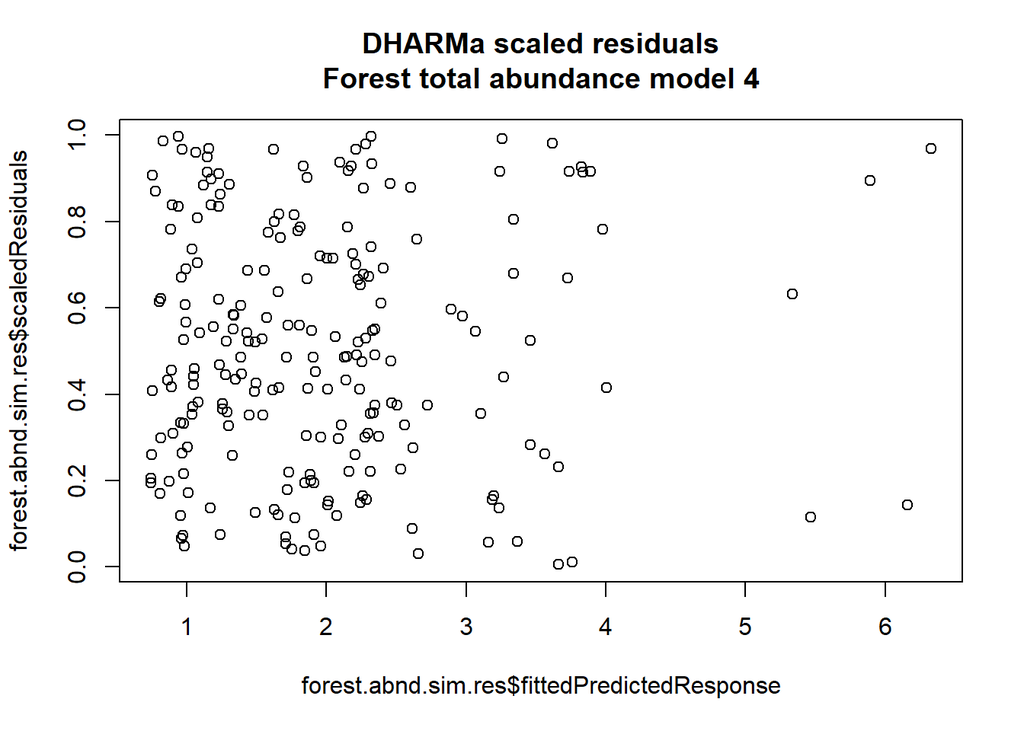

```r
plot(forest.abnd.sim.res$fittedPredictedResponse, forest.abnd.sim.res$scaledResiduals, main = 'DHARMa scaled residuals\nForest total abundance model 4')
```

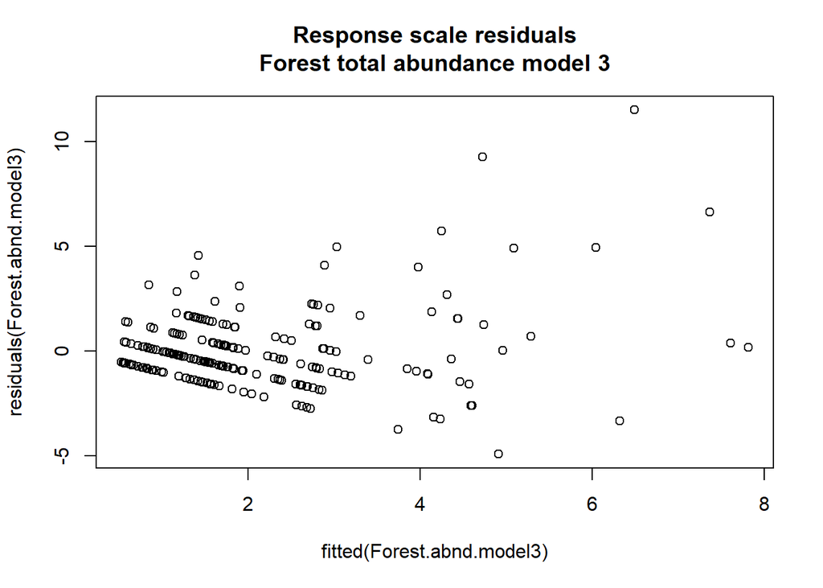

```r
plot(fitted(Forest.abnd.model3), residuals(Forest.abnd.model3), main = 'Response scale residuals\nForest total abundance model 3')
```

We found no significant problems this time. As one research hypothesis was included in the chosen model (subunit), let’s proceed to test for significant differences between all 3 subunits:

```r
EMM <- emmeans(object = Forest.abnd.model3, ~subunit)
test_results_land_use <- test(pairs(EMM), by=NULL, adjust="fdr")
print(test_results_land_use)
```

```
##  contrast                   estimate    SE  df z.ratio p.value
##  Judean Highlands - Carmel   -0.7110 0.288 Inf  -2.468  0.0204
##  Judean Highlands - Galilee   0.0528 0.307 Inf   0.172  0.8634
##  Carmel - Galilee             0.7638 0.293 Inf   2.603  0.0204
##
## Results are given on the log (not the response) scale.
## P value adjustment: fdr method for 3 tests
```

We found significant differences between Carmel and Galilee and between Carmel and Judean Highlands, but not between Galilee and Judean Highlands. Proceed to documenting and backing up the models:

```r
# for (model in c(ls()[grep('*Forest.abnd.model', ls())])){
#   capture.output(cat(model), cat('\n=========\n'), summary(get(model)), cat('\n=========\n'),
#                  file = '../output/Planted Conifer Forest - total abundance model selection.txt', append = T)
# }
# save(list = ls()[grep('*Forest.abnd.model', ls())], file = '../output/Planted Conifer Forest - total abundance models.Rdata')
# capture.output(cat('The best fitting model for total abundance in the Planted Conifer Forest is Forest.abnd.model3.'),
#                summary(Forest.abnd.model3), file = '../output/Planted Conifer Forest total abundance - best fitting model.txt', append = F)

# Create a table comparing total abundance models:
for(model in ls()[grep('*Forest.abnd.model', ls())]){
  total.abnd.comparison <- rbind(total.abnd.comparison,
                                 data.table(unit = 'Planted Conifer Forest', model = model,
                                            no.of.preds = length(attr(get(model)$modelInfo$terms$cond$fixed, 'term.labels')),
                                            AIC = AIC(get(model)), BIC = BIC(get(model)),
                                            data = as.character(get(model)$call$data),
                                            family = as.character(get(model)$call$family),
                                            formula = as.character(get(model)$call$formula)))
}
total.abnd.comparison <- total.abnd.comparison[!(formula %like% '~' | formula %like% 'total.abundance')] # remove redundant rows
total.abnd.comparison <- unique(total.abnd.comparison)
setorder(total.abnd.comparison, unit, AIC)  # Sort by AIC (ascending)
total.abnd.comparison[unit == 'Planted Conifer Forest', .(model, family, formula, no.of.preds, AIC, BIC)] # View the table
```

```
##                             model  family
##                            <char>  <char>
## 1:             Forest.abnd.model3 nbinom2
## 2:             Forest.abnd.model2 nbinom2
## 3:             Forest.abnd.model1 nbinom2
## 4:      Forest.abnd.model.full.NB nbinom2
## 5: Forest.abnd.model.full.Poisson poisson
##                                                                                                    formula
##                                                                                                     <char>
## 1:                              subunit + sin.dist.21.June + cos.dist.21.June + sin.dist.noon + (1 | site)
## 2:                 subunit + year.count + sin.dist.21.June + cos.dist.21.June + sin.dist.noon + (1 | site)
## 3: subunit + year.count + sin.dist.21.June + cos.dist.21.June + sin.dist.noon + cos.dist.noon + (1 | site)
## 4: subunit * year.count + sin.dist.21.June + cos.dist.21.June + sin.dist.noon + cos.dist.noon + (1 | site)
## 5: subunit * year.count + sin.dist.21.June + cos.dist.21.June + sin.dist.noon + cos.dist.noon + (1 | site)
##    no.of.preds      AIC      BIC
##          <num>    <num>    <num>
## 1:           4 802.3144 829.5358
## 2:           5 802.3205 832.9446
## 3:           6 802.8912 836.9179
## 4:           7 804.9048 845.7370
## 5:           7 818.8916 856.3210
```

```r
rm(list = setdiff(ls()[grep('*Forest.abnd.model', ls())], c('Forest.abnd.model3'))) # Clean up
```

We found that the subunit has a significant impact on reptile total abundance, so let’s explore the chosen model’s predictions:

```r
summary(Forest.abnd.model3)
```

```
##  Family: nbinom2  ( log )
## Formula:
## total.abundance ~ subunit + sin.dist.21.June + cos.dist.21.June +
##     sin.dist.noon + (1 | site)
## Data: Forest
##
##      AIC      BIC   logLik deviance df.resid
##    802.3    829.5   -393.2    786.3      214
##
## Random effects:
##
## Conditional model:
##  Groups Name        Variance Std.Dev.
##  site   (Intercept) 0.1497   0.3869
## Number of obs: 222, groups:  site, 15
##
## Dispersion parameter for nbinom2 family (): 5.47
##
## Conditional model:
##                  Estimate Std. Error z value Pr(>|z|)
## (Intercept)       0.88141    0.21508   4.098 4.17e-05 ***
## subunitCarmel     0.71098    0.28812   2.468   0.0136 *
## subunitGalilee   -0.05278    0.30672  -0.172   0.8634
## sin.dist.21.June -0.51820    0.12106  -4.280 1.87e-05 ***
## cos.dist.21.June -0.80927    0.12469  -6.490 8.56e-11 ***
## sin.dist.noon     0.21602    0.13668   1.581   0.1140
## ---
## Signif. codes:  0 '***' 0.001 '**' 0.01 '*' 0.05 '.' 0.1 ' ' 1
```

```r
# Predict by the mean observed values
reptiles[, sort(unique(unit))]
```

```
## [1] Coastal Plain Sands
## [2] Inland Sands
## [3] Loess Covered Areas in the Northern Negev
## [4] Mediterranean-Desert Transition Zone
## [5] Planted Conifer Forests
## 5 Levels: Coastal Plain Sands ... Planted Conifer Forests
```

```r
quantile(reptiles[unit == 'Planted Conifer Forests', .(day.of.year = unique(yday(Date))), by = survey_ID][, day.of.year])
```

```
##   0%  25%  50%  75% 100%
##   98  142  172  217  329
```

```r
# Dates vary from 98 (April 7th) to 329 (November 25th) with a median of 172 (June 21st)

## Calculate the median radian angle of the date and time of sampling and use this for model fit to predict trends

# Create a table to be filled by a loop with predictor values to be used for predictions
Forest.total.abnd.fit.data <- data.table(expand.grid(site = NA,
  dist.21.June.radians = reptiles[unit == 'Planted Conifer Forests', .(dist.21.June.radians = unique(dist.21.June.radians)),
                                  keyby = survey_ID][, median(dist.21.June.radians)],
  dist.noon.radians = reptiles[unit == 'Planted Conifer Forests', .(dist.noon.radians = unique(dist.noon.radians)),
                               keyby = survey_ID][, median(dist.noon.radians)],
  subunit = Forest[, sort(unique(subunit))]))
setorder(Forest.total.abnd.fit.data, subunit, dist.21.June.radians, dist.noon.radians)
Forest.total.abnd.fit.data # seems ok
```

```
##      site dist.21.June.radians dist.noon.radians          subunit
##    <lgcl>                <num>             <num>           <fctr>
## 1:     NA                    0       -0.06981317 Judean Highlands
## 2:     NA                    0       -0.06981317           Carmel
## 3:     NA                    0       -0.06981317          Galilee
```

```r
Forest.total.abnd.fit.data[, ':=' (sin.dist.21.June = sin(dist.21.June.radians), cos.dist.21.June = cos(dist.21.June.radians),
                                   sin.dist.noon = sin(dist.noon.radians))] # Calculate the sin and cosine of the distance from June 21st
Forest.total.abnd.fit.data
```

```
##      site dist.21.June.radians dist.noon.radians          subunit
##    <lgcl>                <num>             <num>           <fctr>
## 1:     NA                    0       -0.06981317 Judean Highlands
## 2:     NA                    0       -0.06981317           Carmel
## 3:     NA                    0       -0.06981317          Galilee
##    sin.dist.21.June cos.dist.21.June sin.dist.noon
##               <num>            <num>         <num>
## 1:                0                1   -0.06975647
## 2:                0                1   -0.06975647
## 3:                0                1   -0.06975647
```

```r
bla <- predict(Forest.abnd.model3, newdata = Forest.total.abnd.fit.data, type = 'response', se.fit = T)
Forest.total.abnd.fit.data[, ':=' (predicted.abnd = bla$fit, predicted.abnd.se = bla$se.fit)]
Forest.total.abnd.fit.data[, .(subunit, predicted.abnd, predicted.abnd.se)]
```

```
##             subunit predicted.abnd predicted.abnd.se
##              <fctr>          <num>             <num>
## 1: Judean Highlands       1.058733         0.2357023
## 2:           Carmel       2.155556         0.4308442
## 3:          Galilee       1.004298         0.2243330
```

Predictions are considerably lower than the observations. Let’s try predicting for range of surveyed dates to see if it a seasonal issue:

```r
Forest.total.abnd.fit.data2 <- data.table(expand.grid(site = NA, subunit = Forest[, unique(subunit)],
                                                      dist.noon.radians = reptiles[unit == 'Planted Conifer Forests', .(dist.noon.radians = unique(dist.noon.radians)), keyby = survey_ID][, median(dist.noon.radians)],
                                                      Date = seq.Date(from = as.Date('2015-04-07'), to = as.Date('2015-11-24'), by = 1)))
Forest.total.abnd.fit.data2
```

```
##        site          subunit dist.noon.radians       Date
##      <lgcl>           <fctr>             <num>     <Date>
##   1:     NA           Carmel       -0.06981317 2015-04-07
##   2:     NA          Galilee       -0.06981317 2015-04-07
##   3:     NA Judean Highlands       -0.06981317 2015-04-07
##   4:     NA           Carmel       -0.06981317 2015-04-08
##   5:     NA          Galilee       -0.06981317 2015-04-08
##  ---
## 692:     NA          Galilee       -0.06981317 2015-11-23
## 693:     NA Judean Highlands       -0.06981317 2015-11-23
## 694:     NA           Carmel       -0.06981317 2015-11-24
## 695:     NA          Galilee       -0.06981317 2015-11-24
## 696:     NA Judean Highlands       -0.06981317 2015-11-24
```

```r
Forest.total.abnd.fit.data2[, ':=' (dist.21.June = yday(Date) - yday('2015-06-21'))]
Forest.total.abnd.fit.data2[, ':=' (dist.21.June.radians = dist.21.June * pi /182.5)]
Forest.total.abnd.fit.data2[, ':=' (sin.dist.21.June = sin(dist.21.June.radians),
                                    cos.dist.21.June = cos(dist.21.June.radians),
                                    sin.dist.noon = sin(dist.noon.radians))]
bla2 <- predict(Forest.abnd.model3, newdata = Forest.total.abnd.fit.data2, type = 'response', se.fit = T)
Forest.total.abnd.fit.data2[, ':=' (predicted.abnd = bla2$fit, predicted.abnd.se = bla2$se.fit)]
Forest.total.abnd.fit.data2[, .(mean.predicted.abnd = mean(predicted.abnd)), keyby = .(subunit)]
```

```
## Key: <subunit>
##             subunit mean.predicted.abnd
##              <fctr>               <num>
## 1: Judean Highlands            1.699377
## 2:           Carmel            3.459893
## 3:          Galilee            1.612004
```

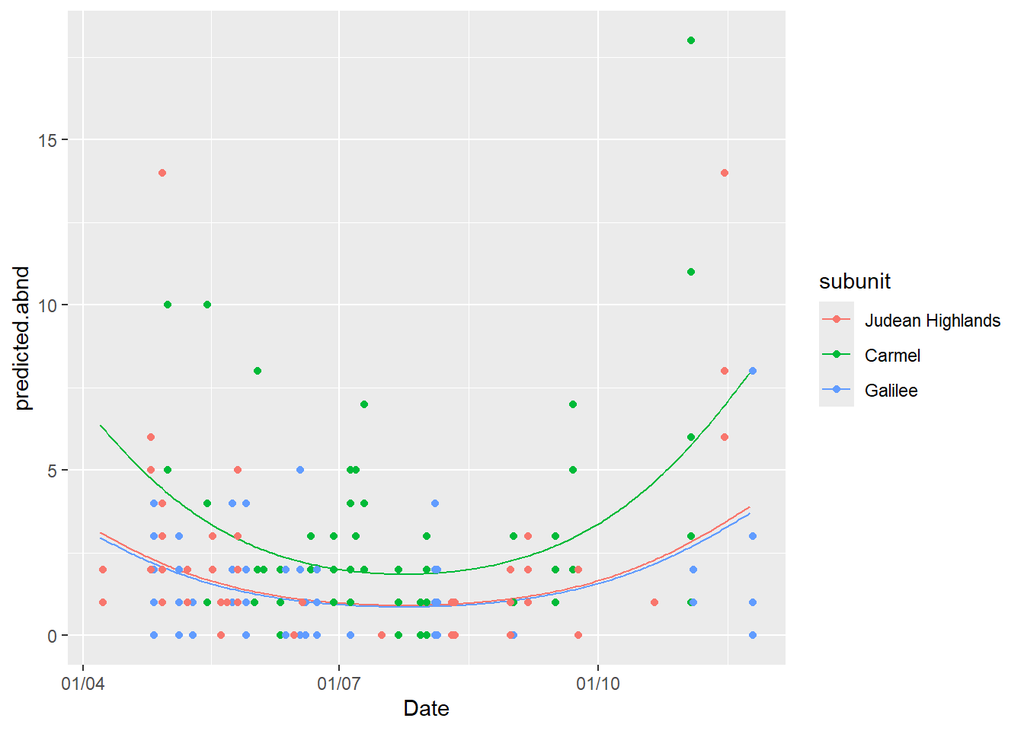

```r
ggplot(data = Forest.total.abnd.fit.data2, aes(x = Date, y = predicted.abnd, color = subunit)) + geom_line() +
  geom_point(data = reptiles[unit %like% 'Forest' & is.rare.in.unit == F, .(total.abnd = sum(count_individuals, na.rm = T)),
                             keyby = .(subunit, survey_ID, Date = as.Date(paste('2015', month(Date), day(Date), sep = '-')))],
             aes(x = Date, y = total.abnd, color = subunit)) + scale_x_date(date_labels = '%d/%m')
```

```r
Forest[, .(mean.abnd = mean(total.abundance, na.rm = T), var.abnd = var(total.abundance, na.rm = T),
           median.abnd = median(total.abundance, na.rm = T)), keyby = subunit]
```

```
## Key: <subunit>
##             subunit mean.abnd var.abnd median.abnd
##              <fctr>     <num>    <num>       <num>
## 1: Judean Highlands  2.148649 6.785820           1
## 2:           Carmel  2.891892 9.248427           2
## 3:          Galilee  1.459459 2.443539           1
```

It seems that seasonal variation is considerable. As there are more observations (and higher abundance) in the spring, let’s predict for May 1st this time:

```r
Forest.total.abnd.fit.data3 <- data.table(expand.grid(site = NA, subunit = Forest[, unique(subunit)],
                                                      dist.noon.radians = reptiles[unit == 'Planted Conifer Forests', .(dist.noon.radians = unique(dist.noon.radians)), keyby = survey_ID][, median(dist.noon.radians)],
                                                      Date = as.Date('2015-05-01')))
Forest.total.abnd.fit.data3
```

```
##      site          subunit dist.noon.radians       Date
##    <lgcl>           <fctr>             <num>     <Date>
## 1:     NA           Carmel       -0.06981317 2015-05-01
## 2:     NA          Galilee       -0.06981317 2015-05-01
## 3:     NA Judean Highlands       -0.06981317 2015-05-01
```

```r
Forest.total.abnd.fit.data3[, ':=' (dist.21.June = yday(Date) - yday('2015-06-21'))]
Forest.total.abnd.fit.data3[, ':=' (dist.21.June.radians = dist.21.June * pi /182.5)]
Forest.total.abnd.fit.data3[, ':=' (sin.dist.21.June = sin(dist.21.June.radians),
                                    cos.dist.21.June = cos(dist.21.June.radians),
                                    sin.dist.noon = sin(dist.noon.radians))]
bla2 <- predict(Forest.abnd.model3, newdata = Forest.total.abnd.fit.data3, type = 'response', se.fit = T)
Forest.total.abnd.fit.data3[, ':=' (predicted.abnd = bla2$fit, predicted.abnd.se = bla2$se.fit)]
Forest.total.abnd.fit.data3[, .(mean.predicted.abnd = mean(predicted.abnd)), keyby = .(subunit)]
```

```
## Key: <subunit>
##             subunit mean.predicted.abnd
##              <fctr>               <num>
## 1: Judean Highlands            2.113052
## 2:           Carmel            4.302127
## 3:          Galilee            2.004410
```

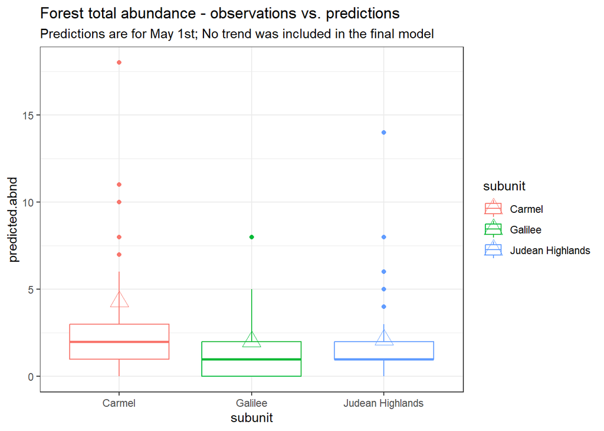

```r
ggplot(data = Forest.total.abnd.fit.data3, aes(x = subunit, y = predicted.abnd, color = subunit))  +
  geom_boxplot(data = reptiles[unit %like% 'Forest' & is.rare.in.unit == F, .(total.abnd = sum(count_individuals, na.rm = T)),
                             keyby = .(subunit, survey_ID)], aes(x = subunit, y = total.abnd, color = subunit)) +
  geom_point(shape = 2, size = 5) + theme_bw() + labs(title = 'Forest total abundance - observations vs. predictions',
                                                      subtitle = 'Predictions are for May 1st; No trend was included in the final model')
```

```r
Forest[, .(mean.abnd = mean(total.abundance, na.rm = T), var.abnd = var(total.abundance, na.rm = T),
           median.abnd = median(total.abundance, na.rm = T)), keyby = subunit]
```

```
## Key: <subunit>
##             subunit mean.abnd var.abnd median.abnd
##              <fctr>     <num>    <num>       <num>
## 1: Judean Highlands  2.148649 6.785820           1
## 2:           Carmel  2.891892 9.248427           2
## 3:          Galilee  1.459459 2.443539           1
```

This seems more or less ok. Proceed to plotting the effect of subunits:

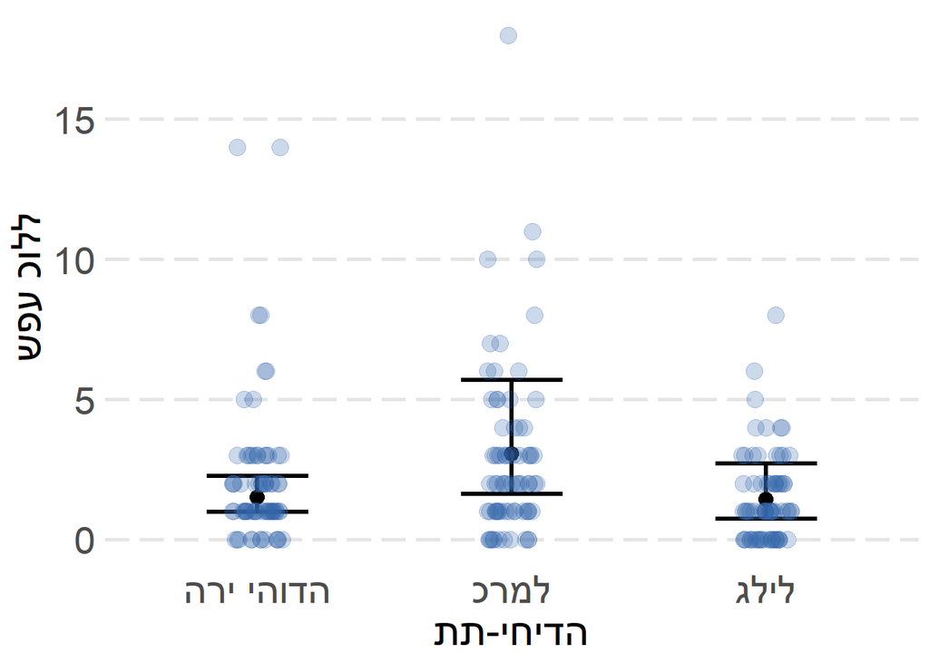

```r
# Effect plot of subunit
Forest.abnd.effect.plot <- effect_plot(model = Forest.abnd.model3, pred = subunit, data = Forest,  colors = "Qual1", point.size = 4,
                                                   line.colors = 'black', point.alpha = 0.25, interval = T, plot.points = T, partial.residuals = F,
                                                   jitter = c(0.1,0), int.type = 'confidence', legend.main = strReverse('תת-יחידה')) +
  theme_minimal() + labs(x = strReverse('תת-יחידה'), y = strReverse('שפע כולל')) +
  scale_x_discrete(labels = c(strReverse('הרי יהודה'), strReverse('כרמל'), strReverse('גליל'))) +
  theme(plot.title = element_text(hjust = 0.5), plot.subtitle = element_text(hjust = 0.5), legend.position = 'bottom',
        text = element_text(family = fontname, size = fontsize), axis.text = element_text(size = fontsize - 1),
        panel.grid.major.y = element_line(color = 'grey90', linetype = 5, linewidth = 1),
        panel.grid.minor = element_blank(), panel.grid.minor.x = element_blank(), panel.grid.major.x = element_blank())
Forest.abnd.effect.plot$layers[[2]]$geom_params$width <- 0.4
Forest.abnd.effect.plot # Note that the order of the subunit is wrong - should be Galilee, Carmel and Judean Highlands (north to south)
```

```r
Cairo::Cairo(file = '../output/Planted Conifer Forest total abundance model3 effect plot - subunits.pdf', width = pdf_width, height = pdf_width*pdf_aspect_ratio,
             type = "PDF", units = "mm")
print(Forest.abnd.effect.plot)
dev.off()
```

# Semi-Desert (Sfar)

```r
# sfar species richness - glmm model selection ----
# Full model, Poisson response

sfar <- alpha.div[unit == 'Mediterranean-Desert Transition Zone']

str(sfar)
```

```
## Classes 'data.table' and 'data.frame':   119 obs. of  23 variables:
##  $ unit               : Factor w/ 5 levels "Coastal Plain Sands",..: 4 4 4 4 4 4 4 4 4 4 ...
##  $ year               : num  2014 2014 2014 2014 2014 ...
##  $ campaign           : Factor w/ 5 levels "T0","T1","T2",..: 1 1 1 1 1 1 1 1 1 1 ...
##  $ subunit            : Factor w/ 3 levels "Carmel","Galilee",..: NA NA NA NA NA NA NA NA NA NA ...
##  $ site               : Factor w/ 35 levels "Aderet","Amatzia",..: 7 7 7 7 7 7 16 16 16 16 ...
##  $ point_name         : Factor w/ 281 levels "Aderet 31.67144877_34.9880248",..: 52 53 54 57 58 61 116 118 119 123 ...
##  $ survey_ID          : Factor w/ 691 levels "T0_Aderet 31.67867469_34.98154177",..: 28 29 30 31 32 33 52 53 54 55 ...
##  $ Date               : Date, format: "2014-05-27" "2014-04-16" ...
##  $ sin.dist.21.June   : num  -0.417 -0.907 0.086 -0.907 -0.907 ...
##  $ cos.dist.21.June   : num  0.909 0.421 0.996 0.421 0.421 ...
##  $ sin.dist.noon      : num  0.556 -0.301 0.399 0.187 0.462 ...
##  $ cos.dist.noon      : num  0.831 0.954 0.917 0.982 0.887 ...
##  $ settlements        : Factor w/ 2 levels "Far","Near": 1 1 1 2 2 2 1 1 1 2 ...
##  $ agriculture        : Factor w/ 2 levels "Far","Near": NA NA NA NA NA NA NA NA NA NA ...
##  $ dunes              : Factor w/ 2 levels "semi-shifting",..: NA NA NA NA NA NA NA NA NA NA ...
##  $ habitat            : Factor w/ 3 levels "bedouin agriculture",..: NA NA NA NA NA NA NA NA NA NA ...
##  $ mean.lon           : num  35.1 35.1 35.1 35.1 35.1 ...
##  $ mean.lat           : num  31.4 31.4 31.4 31.4 31.4 ...
##  $ species.richness   : num  2 2 4 5 2 2 3 1 2 1 ...
##  $ total.abundance    : num  2 2 5 9 6 4 3 1 3 1 ...
##  $ geom.mean.abundance: num  1 1 1.19 1.38 5 ...
##  $ year.count         : num  0 0 0 0 0 0 0 0 0 0 ...
##  $ year.fct           : Factor w/ 8 levels "2014","2015",..: 1 1 1 1 1 1 1 1 1 1 ...
##  - attr(*, "sorted")= chr "unit"
##  - attr(*, ".internal.selfref")=<externalptr>
```

```r
sfar[is.na(settlements) | is.na(year)] # no missing variables
```

```
## Key: <unit>
## Empty data.table (0 rows and 23 cols): unit,year,campaign,subunit,site,point_name...
```

```r
sfar.sp.rich.model.full.Poisson <- glmmTMB(species.richness ~ settlements + sin.dist.21.June + cos.dist.21.June +
                                              sin.dist.noon + cos.dist.noon + (1|site), family = 'poisson', data = sfar)
summary(sfar.sp.rich.model.full.Poisson) # AIC = 424.2; BIC = 443.7. all predictors are insignificant
```

```
##  Family: poisson  ( log )
## Formula:
## species.richness ~ settlements + sin.dist.21.June + cos.dist.21.June +
##     sin.dist.noon + cos.dist.noon + (1 | site)
## Data: sfar
##
##      AIC      BIC   logLik deviance df.resid
##    424.2    443.7   -205.1    410.2      112
##
## Random effects:
##
## Conditional model:
##  Groups Name        Variance Std.Dev.
##  site   (Intercept) 0.03716  0.1928
## Number of obs: 119, groups:  site, 5
##
## Conditional model:
##                  Estimate Std. Error z value Pr(>|z|)
## (Intercept)      -0.07782    0.88059  -0.088    0.930
## settlementsNear   0.13778    0.11897   1.158    0.247
## sin.dist.21.June -0.33552    0.57157  -0.587    0.557
## cos.dist.21.June  0.27484    0.65769   0.418    0.676
## sin.dist.noon    -0.04252    0.13973  -0.304    0.761
## cos.dist.noon     0.58467    0.47024   1.243    0.214
```

```r
cat('PHI = '); deviance(sfar.sp.rich.model.full.Poisson)/df.residual(sfar.sp.rich.model.full.Poisson)
```

```
## PHI =
```

```
## [1] 0.7764989
```

```r
drop1(sfar.sp.rich.model.full.Poisson) # Can drop sin.dist.noon
```

```
## Single term deletions
##
## Model:
## species.richness ~ settlements + sin.dist.21.June + cos.dist.21.June +
##     sin.dist.noon + cos.dist.noon + (1 | site)
##                  Df    AIC
## <none>              424.22
## settlements       1 423.56
## sin.dist.21.June  1 422.57
## cos.dist.21.June  1 422.39
## sin.dist.noon     1 422.31
## cos.dist.noon     1 423.83
```

PHI < 1 so we proceed with Poisson models. We can drop sine diel pattern.

```r
sfar.sp.rich.model1 <- glmmTMB(species.richness ~ settlements + sin.dist.21.June + cos.dist.21.June + cos.dist.noon + (1|site), family = 'poisson', data = sfar)
summary(sfar.sp.rich.model1)
```

```
##  Family: poisson  ( log )
## Formula:
## species.richness ~ settlements + sin.dist.21.June + cos.dist.21.June +
##     cos.dist.noon + (1 | site)
## Data: sfar
##
##      AIC      BIC   logLik deviance df.resid
##    422.3    439.0   -205.2    410.3      113
##
## Random effects:
##
## Conditional model:
##  Groups Name        Variance Std.Dev.
##  site   (Intercept) 0.03821  0.1955
## Number of obs: 119, groups:  site, 5
##
## Conditional model:
##                  Estimate Std. Error z value Pr(>|z|)
## (Intercept)      -0.03021    0.86867  -0.035    0.972
## settlementsNear   0.13475    0.11858   1.136    0.256
## sin.dist.21.June -0.30106    0.56018  -0.537    0.591
## cos.dist.21.June  0.23403    0.64436   0.363    0.716
## cos.dist.noon     0.58325    0.47131   1.238    0.216
```

```r
drop1(sfar.sp.rich.model1) # Can drop sin.dist.noon
```

```
## Single term deletions
##
## Model:
## species.richness ~ settlements + sin.dist.21.June + cos.dist.21.June +
##     cos.dist.noon + (1 | site)
##                  Df    AIC
## <none>              422.31
## settlements       1 421.61
## sin.dist.21.June  1 420.60
## cos.dist.21.June  1 420.44
## cos.dist.noon     1 421.91
```

We can drop also cosine seasonality:

```r
sfar.sp.rich.model2 <- glmmTMB(species.richness ~ settlements + sin.dist.21.June + cos.dist.noon + (1|site), family = 'poisson', data = sfar)
summary(sfar.sp.rich.model2)
```

```
##  Family: poisson  ( log )
## Formula:
## species.richness ~ settlements + sin.dist.21.June + cos.dist.noon +
##     (1 | site)
## Data: sfar
##
##      AIC      BIC   logLik deviance df.resid
##    420.4    434.3   -205.2    410.4      114
##
## Random effects:
##
## Conditional model:
##  Groups Name        Variance Std.Dev.
##  site   (Intercept) 0.04575  0.2139
## Number of obs: 119, groups:  site, 5
##
## Conditional model:
##                  Estimate Std. Error z value Pr(>|z|)
## (Intercept)        0.2413     0.4409   0.547    0.584
## settlementsNear    0.1363     0.1185   1.150    0.250
## sin.dist.21.June  -0.1196     0.2481  -0.482    0.630
## cos.dist.noon      0.5679     0.4700   1.208    0.227
```

```r
drop1(sfar.sp.rich.model2) # Can drop sin.dist.noon
```

```
## Single term deletions
##
## Model:
## species.richness ~ settlements + sin.dist.21.June + cos.dist.noon +
##     (1 | site)
##                  Df    AIC
## <none>              420.44
## settlements       1 419.77
## sin.dist.21.June  1 418.68
## cos.dist.noon     1 419.97
```

We can drop also sine seasonality:

```r
sfar.sp.rich.model3 <- glmmTMB(species.richness ~ settlements + cos.dist.noon + (1|site), family = 'poisson', data = sfar)
summary(sfar.sp.rich.model3)
```

```
##  Family: poisson  ( log )
## Formula:          species.richness ~ settlements + cos.dist.noon + (1 | site)
## Data: sfar
##
##      AIC      BIC   logLik deviance df.resid
##    418.7    429.8   -205.3    410.7      115
##
## Random effects:
##
## Conditional model:
##  Groups Name        Variance Std.Dev.
##  site   (Intercept) 0.04124  0.2031
## Number of obs: 119, groups:  site, 5
##
## Conditional model:
##                 Estimate Std. Error z value Pr(>|z|)
## (Intercept)       0.3031     0.4174   0.726    0.468
## settlementsNear   0.1394     0.1181   1.180    0.238
## cos.dist.noon     0.6028     0.4615   1.306    0.191
```

```r
drop1(sfar.sp.rich.model3)
```

```
## Single term deletions
##
## Model:
## species.richness ~ settlements + cos.dist.noon + (1 | site)
##               Df    AIC
## <none>           418.68
## settlements    1 418.08
## cos.dist.noon  1 418.48
```

We can further drop the distance to settlements:

```r
sfar.sp.rich.model4 <- glmmTMB(species.richness ~ cos.dist.noon + (1|site), family = 'poisson', data = sfar)
summary(sfar.sp.rich.model4)
```

```
##  Family: poisson  ( log )
## Formula:          species.richness ~ cos.dist.noon + (1 | site)
## Data: sfar
##
##      AIC      BIC   logLik deviance df.resid
##    418.1    426.4   -206.0    412.1      116
##
## Random effects:
##
## Conditional model:
##  Groups Name        Variance Std.Dev.
##  site   (Intercept) 0.04084  0.2021
## Number of obs: 119, groups:  site, 5
##
## Conditional model:
##               Estimate Std. Error z value Pr(>|z|)
## (Intercept)     0.2770     0.4188   0.662    0.508
## cos.dist.noon   0.7137     0.4540   1.572    0.116
```

```r
drop1(sfar.sp.rich.model4)
```

```
## Single term deletions
##
## Model:
## species.richness ~ cos.dist.noon + (1 | site)
##               Df    AIC
## <none>           418.08
## cos.dist.noon  1 418.72
```

We can drop the last fixed predictor:

```r
sfar.sp.rich.model.null <- glmmTMB(species.richness ~ (1|site), family = 'poisson', data = sfar)
summary(sfar.sp.rich.model.null)
```

```
##  Family: poisson  ( log )
## Formula:          species.richness ~ (1 | site)
## Data: sfar
##
##      AIC      BIC   logLik deviance df.resid
##    418.7    424.3   -207.4    414.7      117
##
## Random effects:
##
## Conditional model:
##  Groups Name        Variance Std.Dev.
##  site   (Intercept) 0.04313  0.2077
## Number of obs: 119, groups:  site, 5
##
## Conditional model:
##             Estimate Std. Error z value Pr(>|z|)
## (Intercept)   0.9083     0.1101   8.252   <2e-16 ***
## ---
## Signif. codes:  0 '***' 0.001 '**' 0.01 '*' 0.05 '.' 0.1 ' ' 1
```

```r
drop1(sfar.sp.rich.model.null)
```

```
## Single term deletions
##
## Model:
## species.richness ~ (1 | site)
##      Df    AIC
## [1,]    418.72
```

We are now by definition cannot drop any more predictors, as we insist on keeping the site predictor no matter what AIC suggests.

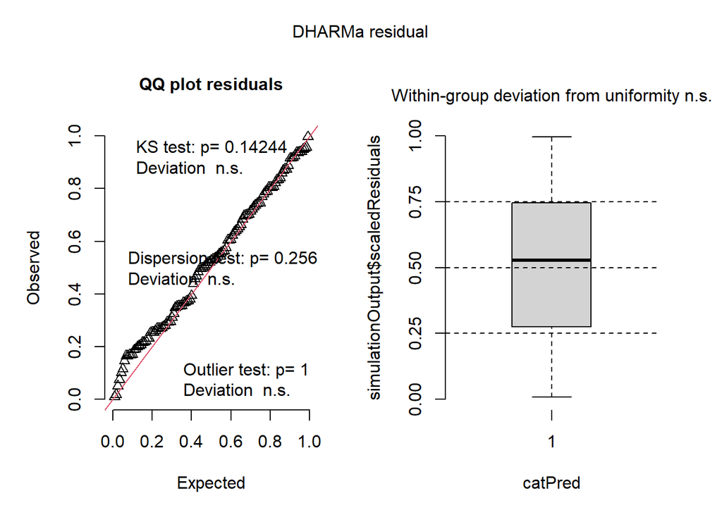

```r
# The chosen model is the null model
sfar.sp.rich.sim.res <- simulateResiduals(sfar.sp.rich.model.null)
plot(sfar.sp.rich.sim.res) # No detected problems
```

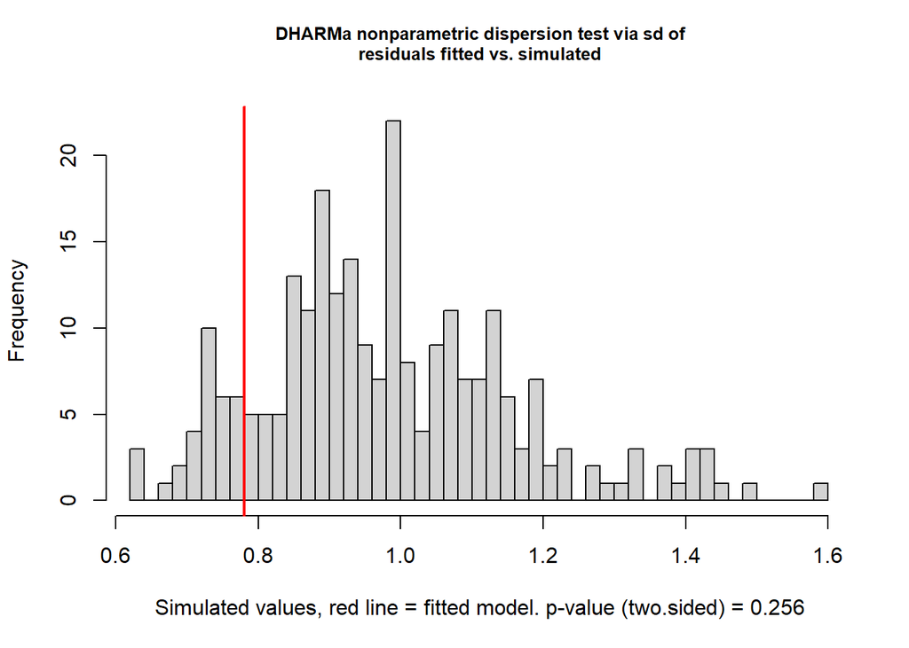

```
##
##  DHARMa nonparametric dispersion test via sd of residuals fitted vs.
##  simulated
##
## data:  simulationOutput
## dispersion = 0.79476, p-value = 0.256
## alternative hypothesis: two.sided
```

```r
testDispersion(sfar.sp.rich.sim.res)
```

```r
testDispersion(sfar.sp.rich.sim.res, alternative = 'less', plot = F)
```

```
##
##  DHARMa nonparametric dispersion test via sd of residuals fitted vs.
##  simulated
##
## data:  simulationOutput
## dispersion = 0.79476, p-value = 0.128
## alternative hypothesis: less
```

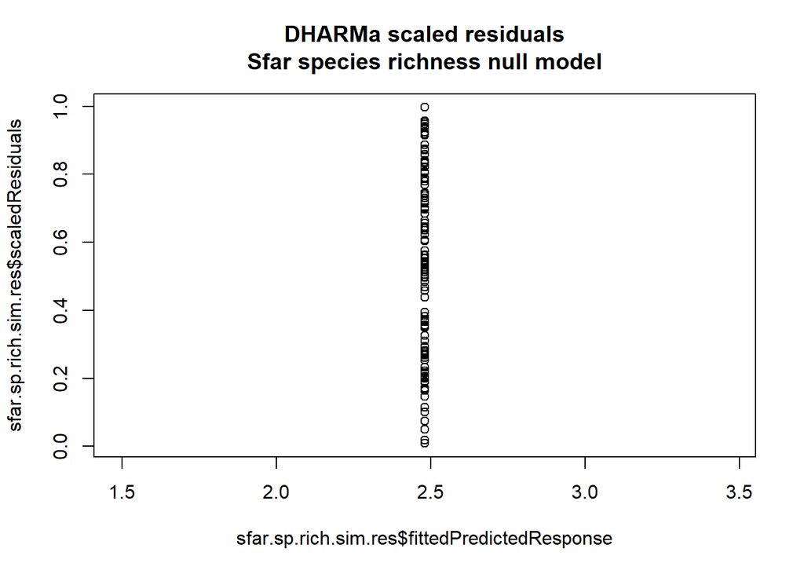

```r
plot(sfar.sp.rich.sim.res$fittedPredictedResponse, sfar.sp.rich.sim.res$scaledResiduals, main = 'DHARMa scaled residuals\nSfar species richness null model')
```

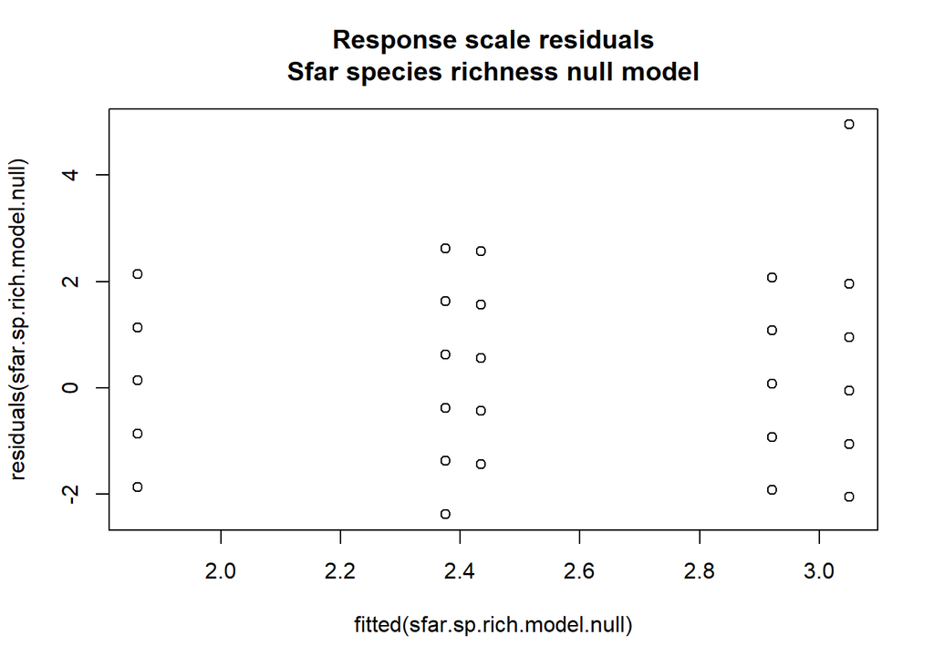

```r
plot(fitted(sfar.sp.rich.model.null), residuals(sfar.sp.rich.model.null), main = 'Response scale residuals\nSfar species richness null model')
```

```r
# for (model in c(ls()[grep('*sfar.sp.rich.model', ls())])){
#   capture.output(cat(model), cat('\n=========\n'), summary(get(model)), cat('\n=========\n'),
#                  file = '../output/sfar - species richness model selection.txt', append = T)
# }

# save(list = ls()[grep('*sfar.sp.rich.model', ls())], file = '../output/Sfar - Species richness models.Rdata')
# capture.output(cat('The best fitting model for species richness in the sfar is sfar.sp.rich.model.null.'),
#                summary(sfar.sp.rich.model.null), file = '../output/sfar species richness - best fitting model.txt', append = F)

# Create a table comparing total abundance models:
for(model in ls()[grep('*sfar.sp.rich.model.', ls())]){
  sp.rich.comparison <- rbind(sp.rich.comparison,
                              data.table(unit = 'sfar', model = model,
                                         no.of.preds = length(attr(get(model)$modelInfo$terms$cond$fixed, 'term.labels')),
                                         AIC = AIC(get(model)), BIC = BIC(get(model)),
                                         data = as.character(get(model)$call$data),
                                         family = as.character(get(model)$call$family),
                                         formula = as.character(get(model)$call$formula)))
}
sp.rich.comparison <- sp.rich.comparison[!(formula %like% '~' | formula %like% 'species.richness')] # remove redundant rows
sp.rich.comparison <- unique(sp.rich.comparison)
setorder(sp.rich.comparison, unit, AIC)  # Sort by AIC (ascending)
sp.rich.comparison[unit == 'sfar', .(model, family, formula, no.of.preds, AIC, BIC)] # View the table
```

```
##                              model  family
##                             <char>  <char>
## 1:             sfar.sp.rich.model4 poisson
## 2:             sfar.sp.rich.model3 poisson
## 3:         sfar.sp.rich.model.null poisson
## 4:             sfar.sp.rich.model2 poisson
## 5:             sfar.sp.rich.model1 poisson
## 6: sfar.sp.rich.model.full.Poisson poisson
##                                                                                           formula
##                                                                                            <char>
## 1:                                                                     cos.dist.noon + (1 | site)
## 2:                                                       settlements + cos.dist.noon + (1 | site)
## 3:                                                                                     (1 | site)
## 4:                                    settlements + sin.dist.21.June + cos.dist.noon + (1 | site)
## 5:                 settlements + sin.dist.21.June + cos.dist.21.June + cos.dist.noon + (1 | site)
## 6: settlements + sin.dist.21.June + cos.dist.21.June + sin.dist.noon + cos.dist.noon + (1 | site)
##    no.of.preds      AIC      BIC
##          <num>    <num>    <num>
## 1:           1 418.0766 426.4139
## 2:           2 418.6797 429.7962
## 3:           0 418.7162 424.2745
## 4:           3 420.4432 434.3388
## 5:           4 422.3110 438.9858
## 6:           5 424.2185 443.6724
```

```r
rm(list = setdiff(ls()[grep('*sfar.sp.rich.model', ls())], c('sfar.sp.rich.model.null'))) # Clean up
```

Again, no researcher hypotheses were supported, so let’s move on to total abundance.

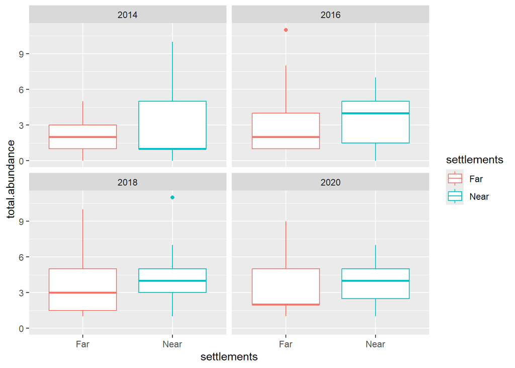

```r
ggplot(data = sfar, aes(x = settlements, y = total.abundance, color = settlements)) + geom_boxplot() + facet_wrap(. ~ year)
```

2018-2020 seem higher than 2014.

```r
# Full model, Poisson response
sfar.abnd.model.full.Poisson <- glmmTMB(total.abundance ~ year.count * settlements + sin.dist.21.June + cos.dist.21.June +
                                           sin.dist.noon + cos.dist.noon + (1|site) , family = 'poisson', data = sfar)
summary(sfar.abnd.model.full.Poisson) # AIC = 524.6 BIC = 549.6. seasonality and trend are significant
```

```
##  Family: poisson  ( log )
## Formula:
## total.abundance ~ year.count * settlements + sin.dist.21.June +
##     cos.dist.21.June + sin.dist.noon + cos.dist.noon + (1 | site)
## Data: sfar
##
##      AIC      BIC   logLik deviance df.resid
##    524.6    549.6   -253.3    506.6      110
##
## Random effects:
##
## Conditional model:
##  Groups Name        Variance Std.Dev.
##  site   (Intercept) 0.02107  0.1451
## Number of obs: 119, groups:  site, 5
##
## Conditional model:
##                            Estimate Std. Error z value Pr(>|z|)
## (Intercept)                -1.47411    0.97749  -1.508   0.1315
## year.count                  0.11014    0.04487   2.454   0.0141 *
## settlementsNear             0.28469    0.17983   1.583   0.1134
## sin.dist.21.June           -1.08524    0.57292  -1.894   0.0582 .
## cos.dist.21.June            1.65336    0.78504   2.106   0.0352 *
## sin.dist.noon               0.01381    0.12274   0.113   0.9104
## cos.dist.noon               0.64807    0.41356   1.567   0.1171
## year.count:settlementsNear -0.04566    0.04606  -0.991   0.3216
## ---
## Signif. codes:  0 '***' 0.001 '**' 0.01 '*' 0.05 '.' 0.1 ' ' 1
```

```r
cat('PHI = '); deviance(sfar.abnd.model.full.Poisson)/df.residual(sfar.abnd.model.full.Poisson)
```

```
## PHI =
```

```
## [1] 1.458868
```

```r
drop1(sfar.abnd.model.full.Poisson) # can drop sine diel pattern
```

```
## Single term deletions
##
## Model:
## total.abundance ~ year.count * settlements + sin.dist.21.June +
##     cos.dist.21.June + sin.dist.noon + cos.dist.noon + (1 | site)
##                        Df    AIC
## <none>                    524.60
## sin.dist.21.June        1 526.57
## cos.dist.21.June        1 527.72
## sin.dist.noon           1 522.61
## cos.dist.noon           1 525.16
## year.count:settlements  1 523.58
```

PHI > 1 so we fit a negative binomial model:

```r
sfar.abnd.model.full.NB <- glmmTMB(total.abundance ~ year.count * settlements + sin.dist.21.June + cos.dist.21.June +
                                           sin.dist.noon + cos.dist.noon + (1|site) , family = 'nbinom2', data = sfar)
summary(sfar.abnd.model.full.NB)
```

```
##  Family: nbinom2  ( log )
## Formula:
## total.abundance ~ year.count * settlements + sin.dist.21.June +
##     cos.dist.21.June + sin.dist.noon + cos.dist.noon + (1 | site)
## Data: sfar
##
##      AIC      BIC   logLik deviance df.resid
##    518.6    546.4   -249.3    498.6      109
##
## Random effects:
##
## Conditional model:
##  Groups Name        Variance Std.Dev.
##  site   (Intercept) 0.002289 0.04784
## Number of obs: 119, groups:  site, 5
##
## Dispersion parameter for nbinom2 family (): 8.32
##
## Conditional model:
##                            Estimate Std. Error z value Pr(>|z|)
## (Intercept)                -2.05245    1.13896  -1.802   0.0715 .
## year.count                  0.12670    0.05097   2.486   0.0129 *
## settlementsNear             0.27446    0.21239   1.292   0.1963
## sin.dist.21.June           -1.28679    0.65251  -1.972   0.0486 *
## cos.dist.21.June            2.12718    0.90095   2.361   0.0182 *
## sin.dist.noon               0.01322    0.14408   0.092   0.9269
## cos.dist.noon               0.80576    0.49365   1.632   0.1026
## year.count:settlementsNear -0.04260    0.05520  -0.772   0.4403
## ---
## Signif. codes:  0 '***' 0.001 '**' 0.01 '*' 0.05 '.' 0.1 ' ' 1
```

```r
drop1(sfar.abnd.model.full.NB)
```

```
## Single term deletions
##
## Model:
## total.abundance ~ year.count * settlements + sin.dist.21.June +
##     cos.dist.21.June + sin.dist.noon + cos.dist.noon + (1 | site)
##                        Df    AIC
## <none>                    518.65
## sin.dist.21.June        1 520.58
## cos.dist.21.June        1 522.03
## sin.dist.noon           1 516.65
## cos.dist.noon           1 519.41
## year.count:settlements  1 517.24
```

AIC is lower (better) than for the Poisson models. We can drop the sine diel pattern:

```r
sfar.abnd.model1 <- glmmTMB(total.abundance ~ year.count * settlements + sin.dist.21.June + cos.dist.21.June + cos.dist.noon + (1|site) , family = 'nbinom2', data = sfar)
summary(sfar.abnd.model1)
```

```
##  Family: nbinom2  ( log )
## Formula:
## total.abundance ~ year.count * settlements + sin.dist.21.June +
##     cos.dist.21.June + cos.dist.noon + (1 | site)
## Data: sfar
##
##      AIC      BIC   logLik deviance df.resid
##    516.7    541.7   -249.3    498.7      110
##
## Random effects:
##
## Conditional model:
##  Groups Name        Variance Std.Dev.
##  site   (Intercept) 0.00213  0.04616
## Number of obs: 119, groups:  site, 5
##
## Dispersion parameter for nbinom2 family (): 8.31
##
## Conditional model:
##                            Estimate Std. Error z value Pr(>|z|)
## (Intercept)                -2.06828    1.12925  -1.832   0.0670 .
## year.count                  0.12660    0.05102   2.481   0.0131 *
## settlementsNear             0.27712    0.21040   1.317   0.1878
## sin.dist.21.June           -1.29778    0.64273  -2.019   0.0435 *
## cos.dist.21.June            2.13721    0.89749   2.381   0.0173 *
## cos.dist.noon               0.80924    0.49234   1.644   0.1002
## year.count:settlementsNear -0.04327    0.05473  -0.791   0.4292
## ---
## Signif. codes:  0 '***' 0.001 '**' 0.01 '*' 0.05 '.' 0.1 ' ' 1
```

```r
drop1(sfar.abnd.model1)
```

```
## Single term deletions
##
## Model:
## total.abundance ~ year.count * settlements + sin.dist.21.June +
##     cos.dist.21.June + cos.dist.noon + (1 | site)
##                        Df    AIC
## <none>                    516.65
## sin.dist.21.June        1 518.74
## cos.dist.21.June        1 520.09
## cos.dist.noon           1 517.46
## year.count:settlements  1 515.28
```

We can drop the interaction:

```r
sfar.abnd.model2 <- glmmTMB(total.abundance ~ year.count + settlements + sin.dist.21.June + cos.dist.21.June + cos.dist.noon + (1|site) , family = 'nbinom2', data = sfar)
summary(sfar.abnd.model2)
```

```
##  Family: nbinom2  ( log )
## Formula:
## total.abundance ~ year.count + settlements + sin.dist.21.June +
##     cos.dist.21.June + cos.dist.noon + (1 | site)
## Data: sfar
##
##      AIC      BIC   logLik deviance df.resid
##    515.3    537.5   -249.6    499.3      111
##
## Random effects:
##
## Conditional model:
##  Groups Name        Variance Std.Dev.
##  site   (Intercept) 0.001809 0.04253
## Number of obs: 119, groups:  site, 5
##
## Dispersion parameter for nbinom2 family (): 8.11
##
## Conditional model:
##                  Estimate Std. Error z value Pr(>|z|)
## (Intercept)      -1.99583    1.12579  -1.773   0.0763 .
## year.count        0.10401    0.04203   2.475   0.0133 *
## settlementsNear   0.14305    0.12449   1.149   0.2505
## sin.dist.21.June -1.32742    0.64017  -2.074   0.0381 *
## cos.dist.21.June  2.16994    0.89754   2.418   0.0156 *
## cos.dist.noon     0.76267    0.48883   1.560   0.1187
## ---
## Signif. codes:  0 '***' 0.001 '**' 0.01 '*' 0.05 '.' 0.1 ' ' 1
```

```r
drop1(sfar.abnd.model2)
```

```
## Single term deletions
##
## Model:
## total.abundance ~ year.count + settlements + sin.dist.21.June +
##     cos.dist.21.June + cos.dist.noon + (1 | site)
##                  Df    AIC
## <none>              515.28
## year.count        1 518.91
## settlements       1 514.59
## sin.dist.21.June  1 517.59
## cos.dist.21.June  1 518.85
## cos.dist.noon     1 515.79
```

We can drop the distance to settlements:

```r
sfar.abnd.model3 <- glmmTMB(total.abundance ~ year.count + sin.dist.21.June + cos.dist.21.June + cos.dist.noon + (1|site) , family = 'nbinom2', data = sfar)
summary(sfar.abnd.model3)
```

```
##  Family: nbinom2  ( log )
## Formula:
## total.abundance ~ year.count + sin.dist.21.June + cos.dist.21.June +
##     cos.dist.noon + (1 | site)
## Data: sfar
##
##      AIC      BIC   logLik deviance df.resid
##    514.6    534.0   -250.3    500.6      112
##
## Random effects:
##
## Conditional model:
##  Groups Name        Variance Std.Dev.
##  site   (Intercept) 0.004549 0.06744
## Number of obs: 119, groups:  site, 5
##
## Dispersion parameter for nbinom2 family (): 7.86
##
## Conditional model:
##                  Estimate Std. Error z value Pr(>|z|)
## (Intercept)      -1.98435    1.13219  -1.753   0.0797 .
## year.count        0.09872    0.04229   2.334   0.0196 *
## sin.dist.21.June -1.32625    0.63866  -2.077   0.0378 *
## cos.dist.21.June  2.10294    0.90095   2.334   0.0196 *
## cos.dist.noon     0.88915    0.48171   1.846   0.0649 .
## ---
## Signif. codes:  0 '***' 0.001 '**' 0.01 '*' 0.05 '.' 0.1 ' ' 1
```

```r
drop1(sfar.abnd.model3)
```

```
## Single term deletions
##
## Model:
## total.abundance ~ year.count + sin.dist.21.June + cos.dist.21.June +
##     cos.dist.noon + (1 | site)
##                  Df    AIC
## <none>              514.59
## year.count        1 517.78
## sin.dist.21.June  1 517.03
## cos.dist.21.June  1 518.03
## cos.dist.noon     1 516.14
```

We can drop the cosine diel pattern since delta AIC < 2:

```r
sfar.abnd.model4 <- glmmTMB(total.abundance ~ year.count + sin.dist.21.June + cos.dist.21.June + (1|site) , family = 'nbinom2', data = sfar)
summary(sfar.abnd.model4)
```

```
##  Family: nbinom2  ( log )
## Formula:
## total.abundance ~ year.count + sin.dist.21.June + cos.dist.21.June +
##     (1 | site)
## Data: sfar
##
##      AIC      BIC   logLik deviance df.resid
##    516.1    532.8   -252.1    504.1      113
##
## Random effects:
##
## Conditional model:
##  Groups Name        Variance Std.Dev.
##  site   (Intercept) 0.0177   0.133
## Number of obs: 119, groups:  site, 5
##
## Dispersion parameter for nbinom2 family (): 7.87
##
## Conditional model:
##                  Estimate Std. Error z value Pr(>|z|)
## (Intercept)      -0.90043    1.01637  -0.886   0.3757
## year.count        0.08767    0.04376   2.003   0.0451 *
## sin.dist.21.June -1.20839    0.64783  -1.865   0.0621 .
## cos.dist.21.June  1.75654    0.93119   1.886   0.0593 .
## ---
## Signif. codes:  0 '***' 0.001 '**' 0.01 '*' 0.05 '.' 0.1 ' ' 1
```

```r
drop1(sfar.abnd.model4)
```

```
## Single term deletions
##
## Model:
## total.abundance ~ year.count + sin.dist.21.June + cos.dist.21.June +
##     (1 | site)
##                  Df    AIC
## <none>              516.14
## year.count        1 518.44
## sin.dist.21.June  1 517.94
## cos.dist.21.June  1 518.26
```

Let’s try to remove sine seasonality as delta AIC < 2 compared to the current model (although not compared to model 3):

```r
sfar.abnd.model5 <- glmmTMB(total.abundance ~ year.count + cos.dist.21.June + (1|site) , family = 'nbinom2', data = sfar)
summary(sfar.abnd.model5)
```

```
##  Family: nbinom2  ( log )
## Formula:          total.abundance ~ year.count + cos.dist.21.June + (1 | site)
## Data: sfar
##
##      AIC      BIC   logLik deviance df.resid
##    517.9    531.8   -254.0    507.9      114
##
## Random effects:
##
## Conditional model:
##  Groups Name        Variance Std.Dev.
##  site   (Intercept) 0.06742  0.2596
## Number of obs: 119, groups:  site, 5
##
## Dispersion parameter for nbinom2 family (): 7.79
##
## Conditional model:
##                  Estimate Std. Error z value Pr(>|z|)
## (Intercept)       0.84236    0.34166   2.466   0.0137 *
## year.count        0.06540    0.03979   1.644   0.1003
## cos.dist.21.June  0.29903    0.42990   0.696   0.4867
## ---
## Signif. codes:  0 '***' 0.001 '**' 0.01 '*' 0.05 '.' 0.1 ' ' 1
```

```r
drop1(sfar.abnd.model5)
```

```
## Single term deletions
##
## Model:
## total.abundance ~ year.count + cos.dist.21.June + (1 | site)
##                  Df    AIC
## <none>              517.94
## year.count        1 518.69
## cos.dist.21.June  1 516.43
```

Now we can also drop cosine seasonality:

```r
sfar.abnd.model6 <- glmmTMB(total.abundance ~ year.count + (1|site) , family = 'nbinom2', data = sfar)
summary(sfar.abnd.model6)
```

```
##  Family: nbinom2  ( log )
## Formula:          total.abundance ~ year.count + (1 | site)
## Data: sfar
##
##      AIC      BIC   logLik deviance df.resid
##    516.4    527.5   -254.2    508.4      115
##
## Random effects:
##
## Conditional model:
##  Groups Name        Variance Std.Dev.
##  site   (Intercept) 0.09336  0.3055
## Number of obs: 119, groups:  site, 5
##
## Dispersion parameter for nbinom2 family (): 7.87
##
## Conditional model:
##             Estimate Std. Error z value Pr(>|z|)
## (Intercept)  1.05305    0.17243   6.107 1.01e-09 ***
## year.count   0.04518    0.02695   1.676   0.0937 .
## ---
## Signif. codes:  0 '***' 0.001 '**' 0.01 '*' 0.05 '.' 0.1 ' ' 1
```

```r
drop1(sfar.abnd.model6)
```

```
## Single term deletions
##
## Model:
## total.abundance ~ year.count + (1 | site)
##            Df    AIC
## <none>        516.43
## year.count  1 517.22
```

Try keeping only the site as a random predictor:

```r
sfar.abnd.model7 <- glmmTMB(total.abundance ~ (1|site) , family = 'nbinom2', data = sfar)
summary(sfar.abnd.model7)
```

```
##  Family: nbinom2  ( log )
## Formula:          total.abundance ~ (1 | site)
## Data: sfar
##
##      AIC      BIC   logLik deviance df.resid
##    517.2    525.6   -255.6    511.2      116
##
## Random effects:
##
## Conditional model:
##  Groups Name        Variance Std.Dev.
##  site   (Intercept) 0.09306  0.3051
## Number of obs: 119, groups:  site, 5
##
## Dispersion parameter for nbinom2 family (): 7.31
##
## Conditional model:
##             Estimate Std. Error z value Pr(>|z|)
## (Intercept)   1.1942     0.1499   7.966 1.64e-15 ***
## ---
## Signif. codes:  0 '***' 0.001 '**' 0.01 '*' 0.05 '.' 0.1 ' ' 1
```

```r
drop1(sfar.abnd.model7)
```

```
## Single term deletions
##
## Model:
## total.abundance ~ (1 | site)
##      Df    AIC
## [1,]    517.22
```

Which leaves us with the model 3 with the lowest AIC (delta AIC > 2 compared to model 7), while model 4 is simplier (has fewer predictors) and its AIC is 516.1 (i.e. delta AIC < 2 from the minimal AIC). Although the seasonality is only marginally significant (p < 0.1), we cannot drop it due to delta AIC constraints. Proceed to model diagnostics:

```r
# The chosen model is sfar.abnd.model4 - trend and seasonality
summary(sfar.abnd.model4)
```

```
##  Family: nbinom2  ( log )
## Formula:
## total.abundance ~ year.count + sin.dist.21.June + cos.dist.21.June +
##     (1 | site)
## Data: sfar
##
##      AIC      BIC   logLik deviance df.resid
##    516.1    532.8   -252.1    504.1      113
##
## Random effects:
##
## Conditional model:
##  Groups Name        Variance Std.Dev.
##  site   (Intercept) 0.0177   0.133
## Number of obs: 119, groups:  site, 5
##
## Dispersion parameter for nbinom2 family (): 7.87
##
## Conditional model:
##                  Estimate Std. Error z value Pr(>|z|)
## (Intercept)      -0.90043    1.01637  -0.886   0.3757
## year.count        0.08767    0.04376   2.003   0.0451 *
## sin.dist.21.June -1.20839    0.64783  -1.865   0.0621 .
## cos.dist.21.June  1.75654    0.93119   1.886   0.0593 .
## ---
## Signif. codes:  0 '***' 0.001 '**' 0.01 '*' 0.05 '.' 0.1 ' ' 1
```

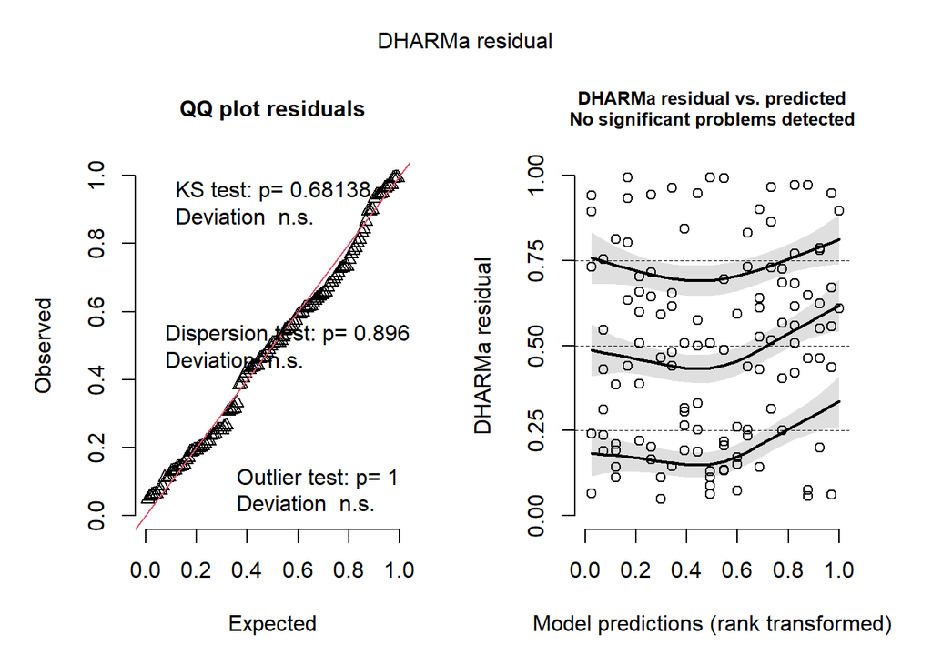

```r
sfar.abnd.sim.res <- simulateResiduals(sfar.abnd.model4)
plot(sfar.abnd.sim.res) # no problems detected
```

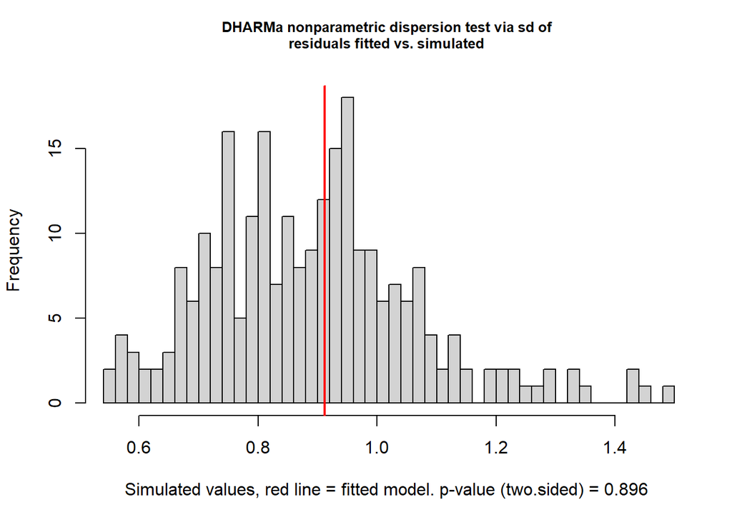

```
##
##  DHARMa nonparametric dispersion test via sd of residuals fitted vs.
##  simulated
##
## data:  simulationOutput
## dispersion = 1.0225, p-value = 0.896
## alternative hypothesis: two.sided
```

```r
testDispersion(sfar.abnd.sim.res)
```

```r
testDispersion(sfar.abnd.sim.res, alternative = 'less', plot = F)
```

```
##
##  DHARMa nonparametric dispersion test via sd of residuals fitted vs.
##  simulated
##
## data:  simulationOutput
## dispersion = 1.0225, p-value = 0.552
## alternative hypothesis: less
```